```python
import pandas as pd
import numpy as np
import matplotlib.pyplot as plt
import seaborn as sns
from sklearn.model_selection import GridSearchCV
```

We have chosen the Pokémon dataset from https://www.kaggle.com/datasets/mariotormo/complete-pokemon-dataset-updated-090420?select=pokedex_%28Update_04.21%29.csv . Our objective is to classify Pokémon types based on the stats and find the model and hyperparameters with the best performance. There are multiple ways of going about this. But first, let's explore the dataset.

# Exploring the dataset

```python
# import the dataset
df = pd.read_csv('data/pokedex.csv')
# Print head
df.head()
```

|  | Unnamed: 0 | pokedex_number | name | german_name | japanese_name | generation | status | species | type_number | type_1 | ... | against_ground | against_flying | against_psychic | against_bug | against_rock | against_ghost | against_dragon | against_dark | against_steel | against_fairy |
| --- | --- | --- | --- | --- | --- | --- | --- | --- | --- | --- | --- | --- | --- | --- | --- | --- | --- | --- | --- | --- | --- |
| 0 | 0 | 1 | Bulbasaur | Bisasam | フシギダネ (Fushigidane) | 1 | Normal | Seed Pokémon | 2 | Grass | ... | 1.0 | 2.0 | 2.0 | 1.0 | 1.0 | 1.0 | 1.0 | 1.0 | 1.0 | 0.5 |
| 1 | 1 | 2 | Ivysaur | Bisaknosp | フシギソウ (Fushigisou) | 1 | Normal | Seed Pokémon | 2 | Grass | ... | 1.0 | 2.0 | 2.0 | 1.0 | 1.0 | 1.0 | 1.0 | 1.0 | 1.0 | 0.5 |
| 2 | 2 | 3 | Venusaur | Bisaflor | フシギバナ (Fushigibana) | 1 | Normal | Seed Pokémon | 2 | Grass | ... | 1.0 | 2.0 | 2.0 | 1.0 | 1.0 | 1.0 | 1.0 | 1.0 | 1.0 | 0.5 |
| 3 | 3 | 3 | Mega Venusaur | Bisaflor | フシギバナ (Fushigibana) | 1 | Normal | Seed Pokémon | 2 | Grass | ... | 1.0 | 2.0 | 2.0 | 1.0 | 1.0 | 1.0 | 1.0 | 1.0 | 1.0 | 0.5 |
| 4 | 4 | 4 | Charmander | Glumanda | ヒトカゲ (Hitokage) | 1 | Normal | Lizard Pokémon | 1 | Fire | ... | 2.0 | 1.0 | 1.0 | 0.5 | 2.0 | 1.0 | 1.0 | 1.0 | 0.5 | 0.5 |

5 rows × 51 columns

```python
# Print info such as data types and number of non-null values
df.info()
```

```
<class 'pandas.core.frame.DataFrame'>
RangeIndex: 1045 entries, 0 to 1044
Data columns (total 51 columns):
 #   Column            Non-Null Count  Dtype
---  ------            --------------  -----
 0   Unnamed: 0        1045 non-null   int64
 1   pokedex_number    1045 non-null   int64
 2   name              1045 non-null   object
 3   german_name       1045 non-null   object
 4   japanese_name     1045 non-null   object
 5   generation        1045 non-null   int64
 6   status            1045 non-null   object
 7   species           1045 non-null   object
 8   type_number       1045 non-null   int64
 9   type_1            1045 non-null   object
```

[output cut: 43 more lines]

```python
# Print summary statistics of numeric types
df.describe()
```

|  | Unnamed: 0 | pokedex_number | generation | type_number | height_m | weight_kg | abilities_number | total_points | hp | attack | ... | against_ground | against_flying | against_psychic | against_bug | against_rock | against_ghost | against_dragon | against_dark | against_steel | against_fairy |
| --- | --- | --- | --- | --- | --- | --- | --- | --- | --- | --- | --- | --- | --- | --- | --- | --- | --- | --- | --- | --- | --- |
| count | 1045.000000 | 1045.000000 | 1045.000000 | 1045.000000 | 1045.000000 | 1044.000000 | 1045.000000 | 1045.000000 | 1045.000000 | 1045.000000 | ... | 1045.000000 | 1045.000000 | 1045.000000 | 1045.000000 | 1045.000000 | 1045.000000 | 1045.000000 | 1045.000000 | 1045.000000 | 1045.000000 |
| mean | 522.000000 | 440.769378 | 4.098565 | 1.529187 | 1.374067 | 71.216571 | 2.268900 | 439.353110 | 70.067943 | 80.476555 | ... | 1.082297 | 1.168900 | 0.977273 | 0.998086 | 1.238278 | 1.018660 | 0.977033 | 1.071053 | 0.981579 | 1.091148 |
| std | 301.809819 | 262.517231 | 2.272788 | 0.499386 | 3.353349 | 132.259911 | 0.803154 | 121.992897 | 26.671411 | 32.432728 | ... | 0.782683 | 0.592145 | 0.501934 | 0.610411 | 0.696560 | 0.568056 | 0.375812 | 0.465178 | 0.501753 | 0.536285 |
| min | 0.000000 | 1.000000 | 1.000000 | 1.000000 | 0.100000 | 0.100000 | 0.000000 | 175.000000 | 1.000000 | 5.000000 | ... | 0.000000 | 0.250000 | 0.000000 | 0.000000 | 0.250000 | 0.000000 | 0.000000 | 0.250000 | 0.000000 | 0.000000 |
| 25% | 261.000000 | 212.000000 | 2.000000 | 1.000000 | 0.600000 | 9.000000 | 2.000000 | 330.000000 | 50.000000 | 55.000000 | ... | 0.500000 | 1.000000 | 1.000000 | 0.500000 | 1.000000 | 1.000000 | 1.000000 | 1.000000 | 0.500000 | 1.000000 |
| 50% | 522.000000 | 436.000000 | 4.000000 | 2.000000 | 1.000000 | 29.500000 | 2.000000 | 458.000000 | 68.000000 | 77.000000 | ... | 1.000000 | 1.000000 | 1.000000 | 1.000000 | 1.000000 | 1.000000 | 1.000000 | 1.000000 | 1.000000 | 1.000000 |
| 75% | 783.000000 | 670.000000 | 6.000000 | 2.000000 | 1.600000 | 70.500000 | 3.000000 | 515.000000 | 82.000000 | 100.000000 | ... | 1.500000 | 1.000000 | 1.000000 | 1.000000 | 2.000000 | 1.000000 | 1.000000 | 1.000000 | 1.000000 | 1.000000 |
| max | 1044.000000 | 898.000000 | 8.000000 | 2.000000 | 100.000000 | 999.900000 | 3.000000 | 1125.000000 | 255.000000 | 190.000000 | ... | 4.000000 | 4.000000 | 4.000000 | 4.000000 | 4.000000 | 4.000000 | 2.000000 | 4.000000 | 4.000000 | 4.000000 |

8 rows × 38 columns

```python
# show all columns with non-numeric type
object_columns = df.select_dtypes(include=['object']).columns

# Print the selected columns
print(object_columns)
```

```
Index(['name', 'german_name', 'japanese_name', 'status', 'species', 'type_1',
       'type_2', 'ability_1', 'ability_2', 'ability_hidden', 'growth_rate',
       'egg_type_1', 'egg_type_2'],
      dtype='object')
```

We'll need to drop some of those columns and encode others to make classification possible.

# Common preprocessing steps

Let's start by removing the columns that contain data which only serve to uniquely identify each Pokémon in the dataset. This includes the name of each Pokémon in 3 different languages, each Pokémon's Pokédex number and an unnamed column with the index of each row.

```python
# Drop the names and index numbers
df.drop(['name', 'Unnamed: 0', 'german_name', 'japanese_name', 'pokedex_number'], axis=1, inplace=True)
# Print the head of the dataframe
df.head()
```

|  | generation | status | species | type_number | type_1 | type_2 | height_m | weight_kg | abilities_number | ability_1 | ... | against_ground | against_flying | against_psychic | against_bug | against_rock | against_ghost | against_dragon | against_dark | against_steel | against_fairy |
| --- | --- | --- | --- | --- | --- | --- | --- | --- | --- | --- | --- | --- | --- | --- | --- | --- | --- | --- | --- | --- | --- |
| 0 | 1 | Normal | Seed Pokémon | 2 | Grass | Poison | 0.7 | 6.9 | 2 | Overgrow | ... | 1.0 | 2.0 | 2.0 | 1.0 | 1.0 | 1.0 | 1.0 | 1.0 | 1.0 | 0.5 |
| 1 | 1 | Normal | Seed Pokémon | 2 | Grass | Poison | 1.0 | 13.0 | 2 | Overgrow | ... | 1.0 | 2.0 | 2.0 | 1.0 | 1.0 | 1.0 | 1.0 | 1.0 | 1.0 | 0.5 |
| 2 | 1 | Normal | Seed Pokémon | 2 | Grass | Poison | 2.0 | 100.0 | 2 | Overgrow | ... | 1.0 | 2.0 | 2.0 | 1.0 | 1.0 | 1.0 | 1.0 | 1.0 | 1.0 | 0.5 |
| 3 | 1 | Normal | Seed Pokémon | 2 | Grass | Poison | 2.4 | 155.5 | 1 | Thick Fat | ... | 1.0 | 2.0 | 2.0 | 1.0 | 1.0 | 1.0 | 1.0 | 1.0 | 1.0 | 0.5 |
| 4 | 1 | Normal | Lizard Pokémon | 1 | Fire | NaN | 0.6 | 8.5 | 2 | Blaze | ... | 2.0 | 1.0 | 1.0 | 0.5 | 2.0 | 1.0 | 1.0 | 1.0 | 0.5 | 0.5 |

5 rows × 46 columns

These aren't all the columns we'll need to remove, however. Next, while some Pokémon do share the same species, the number of Pokémon that share any given species is usually under 10. (The 22 Paradox Pokémon aren't included in this dataset. This makes Mouse Pokémon, of which there are 12 in the dataset, due to the inclusion of alternate forms that some Pokémon have, the only species shared by more than 10 Pokémon.) Most commonly, Pokémon that share the same species, are part of the same evolution family.

What this means is that species are sparsely represented in the dataset. Species are also often only ever tied to one specific type combination. The former would make it annoying to deal with, and the latter goes against the spirit of this project by being far too directly correlated. The species is also more a descriptor and not really a stat. As such, let's remove the species column.

```python
# Drop the species
df.drop(['species'], axis=1, inplace=True)
# Print the head of the dataframe
df.head()
```

|  | generation | status | type_number | type_1 | type_2 | height_m | weight_kg | abilities_number | ability_1 | ability_2 | ... | against_ground | against_flying | against_psychic | against_bug | against_rock | against_ghost | against_dragon | against_dark | against_steel | against_fairy |
| --- | --- | --- | --- | --- | --- | --- | --- | --- | --- | --- | --- | --- | --- | --- | --- | --- | --- | --- | --- | --- | --- |
| 0 | 1 | Normal | 2 | Grass | Poison | 0.7 | 6.9 | 2 | Overgrow | NaN | ... | 1.0 | 2.0 | 2.0 | 1.0 | 1.0 | 1.0 | 1.0 | 1.0 | 1.0 | 0.5 |
| 1 | 1 | Normal | 2 | Grass | Poison | 1.0 | 13.0 | 2 | Overgrow | NaN | ... | 1.0 | 2.0 | 2.0 | 1.0 | 1.0 | 1.0 | 1.0 | 1.0 | 1.0 | 0.5 |
| 2 | 1 | Normal | 2 | Grass | Poison | 2.0 | 100.0 | 2 | Overgrow | NaN | ... | 1.0 | 2.0 | 2.0 | 1.0 | 1.0 | 1.0 | 1.0 | 1.0 | 1.0 | 0.5 |
| 3 | 1 | Normal | 2 | Grass | Poison | 2.4 | 155.5 | 1 | Thick Fat | NaN | ... | 1.0 | 2.0 | 2.0 | 1.0 | 1.0 | 1.0 | 1.0 | 1.0 | 1.0 | 0.5 |
| 4 | 1 | Normal | 1 | Fire | NaN | 0.6 | 8.5 | 2 | Blaze | NaN | ... | 2.0 | 1.0 | 1.0 | 0.5 | 2.0 | 1.0 | 1.0 | 1.0 | 0.5 | 0.5 |

5 rows × 45 columns

Now we're going to remove all the columns that give a direct indication of the types. All the columns named against_[insert type here] indicate type (dis)advantage. Type advantage is the direct result of a Pokémon's type(s). (See Type Chart https://pokemondb.net/type) Again, these go against the spirit of this project by being far too direct.

We'll also remove the column type_number, which indicates how many types the Pokémon has (1 or 2), for the same reason.

```python
#Verify that the last 18 columns are the against_? data
print(df.columns[-18:])
# Drop the species
df.drop(df.columns[-18:], axis=1, inplace=True)
df.drop('type_number', axis=1, inplace=True)
# Print the head of the dataframe
df.head()
```

```
Index(['against_normal', 'against_fire', 'against_water', 'against_electric',
       'against_grass', 'against_ice', 'against_fight', 'against_poison',
       'against_ground', 'against_flying', 'against_psychic', 'against_bug',
       'against_rock', 'against_ghost', 'against_dragon', 'against_dark',
       'against_steel', 'against_fairy'],
      dtype='object')
```

|  | generation | status | type_1 | type_2 | height_m | weight_kg | abilities_number | ability_1 | ability_2 | ability_hidden | ... | speed | catch_rate | base_friendship | base_experience | growth_rate | egg_type_number | egg_type_1 | egg_type_2 | percentage_male | egg_cycles |
| --- | --- | --- | --- | --- | --- | --- | --- | --- | --- | --- | --- | --- | --- | --- | --- | --- | --- | --- | --- | --- | --- |
| 0 | 1 | Normal | Grass | Poison | 0.7 | 6.9 | 2 | Overgrow | NaN | Chlorophyll | ... | 45 | 45.0 | 70.0 | 64.0 | Medium Slow | 2 | Grass | Monster | 87.5 | 20.0 |
| 1 | 1 | Normal | Grass | Poison | 1.0 | 13.0 | 2 | Overgrow | NaN | Chlorophyll | ... | 60 | 45.0 | 70.0 | 142.0 | Medium Slow | 2 | Grass | Monster | 87.5 | 20.0 |
| 2 | 1 | Normal | Grass | Poison | 2.0 | 100.0 | 2 | Overgrow | NaN | Chlorophyll | ... | 80 | 45.0 | 70.0 | 236.0 | Medium Slow | 2 | Grass | Monster | 87.5 | 20.0 |
| 3 | 1 | Normal | Grass | Poison | 2.4 | 155.5 | 1 | Thick Fat | NaN | NaN | ... | 80 | 45.0 | 70.0 | 281.0 | Medium Slow | 2 | Grass | Monster | 87.5 | 20.0 |
| 4 | 1 | Normal | Fire | NaN | 0.6 | 8.5 | 2 | Blaze | NaN | Solar Power | ... | 65 | 45.0 | 70.0 | 62.0 | Medium Slow | 2 | Dragon | Monster | 87.5 | 20.0 |

5 rows × 26 columns

Now let's check for any missing values in the remaining dataframe.

```python
# Check for missing values
print(df.isnull().sum())
```

```
generation            0
status                0
type_1                0
type_2              492
height_m              0
weight_kg             1
abilities_number      0
ability_1             3
ability_2           529
ability_hidden      232
total_points          0
hp                    0
attack                0
defense               0
sp_attack             0
sp_defense            0
speed                 0
catch_rate           18
base_friendship     115
base_experience     120
growth_rate           1
egg_type_number       0
egg_type_1            3
egg_type_2          760
percentage_male     173
egg_cycles            1
dtype: int64
```

At first there appear to be a lot of missing values. However, for most missing values, their absence is actually correct. For example, plenty of Pokémon don't have a second or hidden ability.

That said, there are plenty of actual missing values, so let's deal with those. Let's start by going over what we're dealing with.

```python
print("Missing weight_kg: ",  np.where(df['weight_kg'].isnull()))
```

```
Missing weight_kg:  (array([1033], dtype=int64),)
```

Taking a quick look in the original dataset reveals this corresponds with Eternatus Eternamax.

```python
print("Missing ability_1: ",  np.where(df['ability_1'].isnull()))
```

```
Missing ability_1:  (array([  33,  172, 1033], dtype=int64),)
```

Taking a quick look in the original dataset reveals these correspond with Partner Pikachu, Partner Eevee and Eternatus Eternamax.

```python
# Drop catch_rate, base_friendship and base_experience
df.drop(['catch_rate', 'base_friendship', 'base_experience', 'percentage_male'], axis=1, inplace=True)

# Print the head of the dataframe
df.head()
```

|  | generation | status | type_1 | type_2 | height_m | weight_kg | abilities_number | ability_1 | ability_2 | ability_hidden | ... | attack | defense | sp_attack | sp_defense | speed | growth_rate | egg_type_number | egg_type_1 | egg_type_2 | egg_cycles |
| --- | --- | --- | --- | --- | --- | --- | --- | --- | --- | --- | --- | --- | --- | --- | --- | --- | --- | --- | --- | --- | --- |
| 0 | 1 | Normal | Grass | Poison | 0.7 | 6.9 | 2 | Overgrow | NaN | Chlorophyll | ... | 49 | 49 | 65 | 65 | 45 | Medium Slow | 2 | Grass | Monster | 20.0 |
| 1 | 1 | Normal | Grass | Poison | 1.0 | 13.0 | 2 | Overgrow | NaN | Chlorophyll | ... | 62 | 63 | 80 | 80 | 60 | Medium Slow | 2 | Grass | Monster | 20.0 |
| 2 | 1 | Normal | Grass | Poison | 2.0 | 100.0 | 2 | Overgrow | NaN | Chlorophyll | ... | 82 | 83 | 100 | 100 | 80 | Medium Slow | 2 | Grass | Monster | 20.0 |
| 3 | 1 | Normal | Grass | Poison | 2.4 | 155.5 | 1 | Thick Fat | NaN | NaN | ... | 100 | 123 | 122 | 120 | 80 | Medium Slow | 2 | Grass | Monster | 20.0 |
| 4 | 1 | Normal | Fire | NaN | 0.6 | 8.5 | 2 | Blaze | NaN | Solar Power | ... | 52 | 43 | 60 | 50 | 65 | Medium Slow | 2 | Dragon | Monster | 20.0 |

5 rows × 22 columns

```python
print("Missing growth_rate: ",  np.where(df['growth_rate'].isnull()))
```

```
Missing growth_rate:  (array([658], dtype=int64),)
```

Taking a quick look in the original dataset reveals this corresponds with Galarian Darmanitan Zen Mode.

```python
print("Missing egg_type_1: ",  np.where(df['egg_type_1'].isnull()))
```

```
Missing egg_type_1:  (array([ 33, 172, 658], dtype=int64),)
```

Taking a quick look in the original dataset reveals these correspond with Partner Pikachu, Partner Eevee and Galarian Darmanitan Zen Mode.

It's worth noting that egg_type_number actually lists these as having 0 egg groups, which is incorrect. (It might have been based the total number of values across egg_type_1 and egg_type_2, thereby erroneously taking the missing values into account.)

This means egg_type_number, egg_type_1 and egg_type_2 will need to be corrected.

```python
print(np.where(df['egg_cycles'].isnull()))
```

```
(array([658], dtype=int64),)
```

Taking a quick look in the original dataset reveals this corresponds with Galarian Darmanitan Zen Mode.

Now that we know what we're dealing with, let's handle these missing values.

In total, there are 4 Pokémon (rows) in the dataset that are still actually missing values: Partner Pikachu, Partner Eevee, Galarian Darmanitan Zen Mode and Eternatus Eternamax.

For Partner Pikachu (row 33) and Partner Eevee (row 172), we need to fix the following: ability_1, egg_type_number, egg_type_1 and egg_type_2

```python
#Partner Pikachu
print("Partner Pikachu ability_1 : ", df['ability_1'][33]) #to show Partner Pikachu's ability_1 is nan
df['ability_1'][33] = df['ability_1'][32]                  #Parner Pikachu's ability_1 is the same as regular Pikachu (row 32)
print("(Updated) Partner Pikachu ability_1 : ", df['ability_1'][33]) #to show Partner Pikachu's ability_1 now has the correct value

print("Partner Pikachu egg_type_number : ", df['egg_type_number'][33]) #nan
df['egg_type_number'][33] = df['egg_type_number'][32]                  #it's the same as regular Pikachu (row 32)
print("(Updated) Partner Pikachu egg_type_number : ", df['egg_type_number'][33]) #now has the correct value

print("Partner Pikachu egg_type_1 : ", df['egg_type_1'][33]) #nan
df['egg_type_1'][33] = df['egg_type_1'][32]                  #it's the same as regular Pikachu (row 32)
print("(Updated) Partner Pikachu egg_type_1 : ", df['egg_type_1'][33]) #now has the correct value

#(Partner) Pikachu has two egg types
print("Partner Pikachu egg_type_2 : ", df['egg_type_2'][33]) #nan
df['egg_type_2'][33] = df['egg_type_2'][32]                  #it's the same as regular Pikachu (row 32)
print("(Updated) Partner Pikachu egg_type_2 : ", df['egg_type_2'][33]) #now has the correct value
```

```
Partner Pikachu ability_1 :  nan
(Updated) Partner Pikachu ability_1 :  Static
Partner Pikachu egg_type_number :  0
(Updated) Partner Pikachu egg_type_number :  2
Partner Pikachu egg_type_1 :  nan
(Updated) Partner Pikachu egg_type_1 :  Fairy
Partner Pikachu egg_type_2 :  nan
(Updated) Partner Pikachu egg_type_2 :  Field
```

[output not shown]

[output cut: 9 more lines]

[output not shown]

```python
#Partner Eevee
print("Partner Eevee ability_1 : ", df['ability_1'][172])           #to show Partner Eevee's ability_1 is nan
df['ability_1'][172] = df['ability_1'][171]                         #Parner Eevee's ability_1 is the same as regular Eevee (row 171)
print("(Updated) Partner Eevee ability_1 : ", df['ability_1'][172]) #to show Partner Pikachu's ability_1 now has the correct value

print("Partner Eevee egg_type_number : ", df['egg_type_number'][172])           #nan
df['egg_type_number'][172] = df['egg_type_number'][171]                         #it's the same as regular Eevee (row 171)
print("(Updated) Partner Eevee egg_type_number : ", df['egg_type_number'][172]) #now has the correct value

print("Partner Eevee egg_type_1 : ", df['egg_type_1'][172])           #nan
df['egg_type_1'][172] = df['egg_type_1'][171]                         #it's the same as regular Eevee (row 171)
print("(Updated) Partner Eevee egg_type_1 : ", df['egg_type_1'][172]) #now has the correct value

#(Partner) Eevee only has one egg type, so this won't change anything
print("Partner Eevee egg_type_2 : ", df['egg_type_2'][172])           #nan
df['egg_type_2'][172] = df['egg_type_2'][171]                         #it's the same as regular Eevee (row 171)
print("(Updated) Partner Eevee egg_type_2 : ", df['egg_type_2'][172]) #now has the correct value, still nan
```

```
Partner Eevee ability_1 :  nan
(Updated) Partner Eevee ability_1 :  Run Away
Partner Eevee egg_type_number :  0
(Updated) Partner Eevee egg_type_number :  1
Partner Eevee egg_type_1 :  nan
(Updated) Partner Eevee egg_type_1 :  Field
Partner Eevee egg_type_2 :  nan
(Updated) Partner Eevee egg_type_2 :  nan
```

[output not shown]

[output cut: 9 more lines]

[output not shown]

For Galarian Darmanitan Zen Mode (row 658), we need to fix the following: growth_rate, egg_type_number, egg_type_1, egg_type_2, egg_cycles

```python
#Galarian Darmanitan Zen Mode
print("Galarian Darmanitan Zen Mode growth_rate : ", df['growth_rate'][658]) #to show Galarian Darmanitan Zen Mode's growth_rate is nan
df['growth_rate'][658] = df['growth_rate'][656]                              #Galarian Darmanitan Zen Mode's growth_rate is the same as every
                                                                             #other form of Darmanitan (rows 655, 656, 657), Medium Slow
print("(Updated) Galarian Darmanitan Zen Mode growth_rate : ", df['growth_rate'][658]) #to show Galarian Darmanitan Zen Mode's growth_rate
                                                                                       #now has the correct value

print("Galarian Darmanitan Zen Mode egg_type_number : ", df['egg_type_number'][658])           #nan
df['egg_type_number'][658] = df['egg_type_number'][656]  #it's the same as any other form of Darmanitan (rows 655, 656, 657)
print("(Updated) Galarian Darmanitan Zen Mode egg_type_number : ", df['egg_type_number'][658]) #now has the correct value

print("Galarian Darmanitan Zen Mode egg_type_1 : ", df['egg_type_1'][658])       #nan
df['egg_type_1'][658] = df['egg_type_1'][656]  #it's the same as any other form of Darmanitan (rows 655, 656, 657)
print("(Updated) Galarian Darmanitan Zen Mode egg_type_1 : ", df['egg_type_1'][658]) #now has the correct value

#(Galarian) Darmanitan (Zen Mode) only has one egg type, so this won't change anything
print("Galarian Darmanitan Zen Mode egg_type_2 : ", df['egg_type_2'][658])        #nan
df['egg_type_2'][658] = df['egg_type_2'][656]  #it's the same as any other form of Darmanitan (rows 655, 656, 657)
print("(Updated) Galarian Darmanitan Zen Mode egg_type_2 : ", df['egg_type_2'][658]) #now has the correct value, still nan

print("Galarian Darmanitan Zen Mode egg_cycles : ", df['egg_cycles'][658]) #nan
df['egg_cycles'][658] = df['egg_cycles'][656]  #it's the same as any other form of Darmanitan (rows 655, 656, 657)
print("(Updated) Galarian Darmanitan Zen Mode egg_cycles : ", df['egg_cycles'][658]) #now has the correct value
```

```
Galarian Darmanitan Zen Mode growth_rate :  nan
(Updated) Galarian Darmanitan Zen Mode growth_rate :  Medium Slow
Galarian Darmanitan Zen Mode egg_type_number :  0
(Updated) Galarian Darmanitan Zen Mode egg_type_number :  1
Galarian Darmanitan Zen Mode egg_type_1 :  nan
(Updated) Galarian Darmanitan Zen Mode egg_type_1 :  Field
Galarian Darmanitan Zen Mode egg_type_2 :  nan
(Updated) Galarian Darmanitan Zen Mode egg_type_2 :  nan
Galarian Darmanitan Zen Mode egg_cycles :  nan
(Updated) Galarian Darmanitan Zen Mode egg_cycles :  20.0
```

[output not shown]

[output cut: 25 more lines]

[output not shown]

Lastly, there's Eternatus Eternamax (row 1033). For this one, we'd need to fix weight_kg and ability_1.

Now, ability_1 wouldn't be hard to fix, but it turns out that the missing value for weight_kg is actually correct. It's a trait of Gigantamax Pokémon. (Eternamax is a type of Gigantamax.) However, for some reason, Eternatus Eternamax is the only Gigantamax form that's in the dataset.

Because it's the only one in the dataset and for simplicity's sake, we're just going to remove row 1033 from the dataframe.

```python
df.drop(index=1033, axis=0, inplace=True)
```

Now let's check the number of missing values again.

```python
# Check for missing values
print(df.isnull().sum())
```

```
generation            0
status                0
type_1                0
type_2              492
height_m              0
weight_kg             0
abilities_number      0
ability_1             0
ability_2           528
ability_hidden      231
total_points          0
hp                    0
attack                0
defense               0
sp_attack             0
sp_defense            0
speed                 0
growth_rate           0
egg_type_number       0
egg_type_1            0
egg_type_2          758
egg_cycles            0
dtype: int64
```

```python
df.info()
```

```
<class 'pandas.core.frame.DataFrame'>
Index: 1044 entries, 0 to 1044
Data columns (total 22 columns):
 #   Column            Non-Null Count  Dtype
---  ------            --------------  -----
 0   generation        1044 non-null   int64
 1   status            1044 non-null   object
 2   type_1            1044 non-null   object
 3   type_2            552 non-null    object
 4   height_m          1044 non-null   float64
 5   weight_kg         1044 non-null   float64
 6   abilities_number  1044 non-null   int64
 7   ability_1         1044 non-null   object
 8   ability_2         516 non-null    object
 9   ability_hidden    813 non-null    object
 10  total_points      1044 non-null   int64
 11  hp                1044 non-null   int64
 12  attack            1044 non-null   int64
 13  defense           1044 non-null   int64
 14  sp_attack         1044 non-null   int64
 15  sp_defense        1044 non-null   int64
 16  speed             1044 non-null   int64
 17  growth_rate       1044 non-null   object
 18  egg_type_number   1044 non-null   int64
 19  egg_type_1        1044 non-null   object
 20  egg_type_2        286 non-null    object
 21  egg_cycles        1044 non-null   float64
dtypes: float64(3), int64(10), object(9)
memory usage: 187.6+ KB
```

We'll need to fill up these missing values

[output not shown]

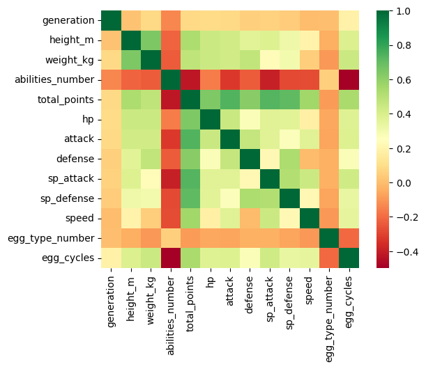

```python
# Plot the correlation matrix
sns.heatmap(df.select_dtypes(include=[np.number, bool]).corr(), square=True, cmap='RdYlGn');
```

In addition to the generation, the number of egg types also has little correlation with the other stats.

The number of abilities ranges between having no correlation and having a somewhat negative correlation with the other stats. (Interesting. Could this be because of balancing? Some other reason?)

There's also a lack of correlation between speed and weight. This goes against what one might initially expect (that heavier Pokémon are slower). However, Pokémon come in a wide range of sizes and vary in the materials they're composed of, so perhaps it shouldn't be surprising that speed and weight aren't correlated.

Dropping columns we don't need

We will handle the missing values in type_2, ability_2, ability_hidden, and egg_type_2 by filling it up by a 'None' value. It is normal that some pokémon don't have a second or hidden ability or (egg) type.

```python
# Handling missing values in 'Type 2' column
df['type_2'].fillna('None', inplace=True)
df['ability_2'].fillna('None', inplace=True)
df['ability_hidden'].fillna('None', inplace=True)
df['egg_type_2'].fillna('None', inplace=True)

print(df.isnull().sum())

df.head()
```

```
generation          0
status              0
type_1              0
type_2              0
height_m            0
weight_kg           0
abilities_number    0
ability_1           0
ability_2           0
ability_hidden      0
total_points        0
hp                  0
attack              0
defense             0
sp_attack           0
sp_defense          0
speed               0
growth_rate         0
egg_type_number     0
egg_type_1          0
egg_type_2          0
egg_cycles          0
dtype: int64
```

|  | generation | status | type_1 | type_2 | height_m | weight_kg | abilities_number | ability_1 | ability_2 | ability_hidden | ... | attack | defense | sp_attack | sp_defense | speed | growth_rate | egg_type_number | egg_type_1 | egg_type_2 | egg_cycles |
| --- | --- | --- | --- | --- | --- | --- | --- | --- | --- | --- | --- | --- | --- | --- | --- | --- | --- | --- | --- | --- | --- |
| 0 | 1 | Normal | Grass | Poison | 0.7 | 6.9 | 2 | Overgrow | None | Chlorophyll | ... | 49 | 49 | 65 | 65 | 45 | Medium Slow | 2 | Grass | Monster | 20.0 |
| 1 | 1 | Normal | Grass | Poison | 1.0 | 13.0 | 2 | Overgrow | None | Chlorophyll | ... | 62 | 63 | 80 | 80 | 60 | Medium Slow | 2 | Grass | Monster | 20.0 |
| 2 | 1 | Normal | Grass | Poison | 2.0 | 100.0 | 2 | Overgrow | None | Chlorophyll | ... | 82 | 83 | 100 | 100 | 80 | Medium Slow | 2 | Grass | Monster | 20.0 |
| 3 | 1 | Normal | Grass | Poison | 2.4 | 155.5 | 1 | Thick Fat | None | None | ... | 100 | 123 | 122 | 120 | 80 | Medium Slow | 2 | Grass | Monster | 20.0 |
| 4 | 1 | Normal | Fire | None | 0.6 | 8.5 | 2 | Blaze | None | Solar Power | ... | 52 | 43 | 60 | 50 | 65 | Medium Slow | 2 | Dragon | Monster | 20.0 |

5 rows × 22 columns

Because scikit-learn does not accept non-numerical features, we need to one-hot encode the categorical columns by creating dummy variables.

```python
df_one_hot = pd.get_dummies(df.drop(['type_1', 'type_2'], axis=1))
df_one_hot.head() # to check if it worked
```

|  | generation | height_m | weight_kg | abilities_number | total_points | hp | attack | defense | sp_attack | sp_defense | ... | egg_type_2_Field | egg_type_2_Flying | egg_type_2_Grass | egg_type_2_Human-Like | egg_type_2_Mineral | egg_type_2_Monster | egg_type_2_None | egg_type_2_Water 1 | egg_type_2_Water 2 | egg_type_2_Water 3 |
| --- | --- | --- | --- | --- | --- | --- | --- | --- | --- | --- | --- | --- | --- | --- | --- | --- | --- | --- | --- | --- | --- |
| 0 | 1 | 0.7 | 6.9 | 2 | 318 | 45 | 49 | 49 | 65 | 65 | ... | False | False | False | False | False | True | False | False | False | False |
| 1 | 1 | 1.0 | 13.0 | 2 | 405 | 60 | 62 | 63 | 80 | 80 | ... | False | False | False | False | False | True | False | False | False | False |
| 2 | 1 | 2.0 | 100.0 | 2 | 525 | 80 | 82 | 83 | 100 | 100 | ... | False | False | False | False | False | True | False | False | False | False |
| 3 | 1 | 2.4 | 155.5 | 1 | 625 | 80 | 100 | 123 | 122 | 120 | ... | False | False | False | False | False | True | False | False | False | False |
| 4 | 1 | 0.6 | 8.5 | 2 | 309 | 39 | 52 | 43 | 60 | 50 | ... | False | False | False | False | False | True | False | False | False | False |

5 rows × 544 columns

```python
df = pd.concat([df_one_hot, df[['type_1', 'type_2']]], axis=1)
df.head()
preprocessed_df = df.copy()
```

# Multi-class classification

## Accounting for Order of Types

We make a new column 'Types' where the combination of type 1 and type 2 are stored in tuples, which is ordered by default

```python
df = preprocessed_df.copy()

# Separate features and labels
X = df.drop(columns=['type_1', 'type_2'])

# Combine Type 1 and Type 2 into a single column
df['Types'] = df[['type_1', 'type_2']].apply(lambda x: tuple(filter(lambda y: pd.notna(y), x)), axis=1)
df.Types = df.Types.astype(str)

print(df['Types'][0])
print(len(df['Types'].unique()))


# drop the Type 1 and Type 2 columns
df.drop(['type_1', 'type_2'], axis=1, inplace=True)

# print head
df.head()
```

```
('Grass', 'Poison')
192
```

|  | generation | height_m | weight_kg | abilities_number | total_points | hp | attack | defense | sp_attack | sp_defense | ... | egg_type_2_Flying | egg_type_2_Grass | egg_type_2_Human-Like | egg_type_2_Mineral | egg_type_2_Monster | egg_type_2_None | egg_type_2_Water 1 | egg_type_2_Water 2 | egg_type_2_Water 3 | Types |
| --- | --- | --- | --- | --- | --- | --- | --- | --- | --- | --- | --- | --- | --- | --- | --- | --- | --- | --- | --- | --- | --- |
| 0 | 1 | 0.7 | 6.9 | 2 | 318 | 45 | 49 | 49 | 65 | 65 | ... | False | False | False | False | True | False | False | False | False | ('Grass', 'Poison') |
| 1 | 1 | 1.0 | 13.0 | 2 | 405 | 60 | 62 | 63 | 80 | 80 | ... | False | False | False | False | True | False | False | False | False | ('Grass', 'Poison') |
| 2 | 1 | 2.0 | 100.0 | 2 | 525 | 80 | 82 | 83 | 100 | 100 | ... | False | False | False | False | True | False | False | False | False | ('Grass', 'Poison') |
| 3 | 1 | 2.4 | 155.5 | 1 | 625 | 80 | 100 | 123 | 122 | 120 | ... | False | False | False | False | True | False | False | False | False | ('Grass', 'Poison') |
| 4 | 1 | 0.6 | 8.5 | 2 | 309 | 39 | 52 | 43 | 60 | 50 | ... | False | False | False | False | True | False | False | False | False | ('Fire', 'None') |

5 rows × 545 columns

[output not shown]

[figure not shown]

```python
# show the distribution of pokemon types
sns.countplot(df, y='Types');
```

```python
singleton_classes = df['Types'].value_counts()[df['Types'].value_counts() == 1].index.tolist()
singleton_data = df[df['Types'].isin(singleton_classes)]
other_data = df[~df['Types'].isin(singleton_classes)]

print("Number of singleton classes",len(singleton_classes))
print("number of unique type combinations",len(df['Types'].unique()))
print(len(df['Types']))
df.head()
```

```
Number of singleton classes 41
number of unique type combinations 192
1044
```

|  | generation | height_m | weight_kg | abilities_number | total_points | hp | attack | defense | sp_attack | sp_defense | ... | egg_type_2_Flying | egg_type_2_Grass | egg_type_2_Human-Like | egg_type_2_Mineral | egg_type_2_Monster | egg_type_2_None | egg_type_2_Water 1 | egg_type_2_Water 2 | egg_type_2_Water 3 | Types |
| --- | --- | --- | --- | --- | --- | --- | --- | --- | --- | --- | --- | --- | --- | --- | --- | --- | --- | --- | --- | --- | --- |
| 0 | 1 | 0.7 | 6.9 | 2 | 318 | 45 | 49 | 49 | 65 | 65 | ... | False | False | False | False | True | False | False | False | False | ('Grass', 'Poison') |
| 1 | 1 | 1.0 | 13.0 | 2 | 405 | 60 | 62 | 63 | 80 | 80 | ... | False | False | False | False | True | False | False | False | False | ('Grass', 'Poison') |
| 2 | 1 | 2.0 | 100.0 | 2 | 525 | 80 | 82 | 83 | 100 | 100 | ... | False | False | False | False | True | False | False | False | False | ('Grass', 'Poison') |
| 3 | 1 | 2.4 | 155.5 | 1 | 625 | 80 | 100 | 123 | 122 | 120 | ... | False | False | False | False | True | False | False | False | False | ('Grass', 'Poison') |
| 4 | 1 | 0.6 | 8.5 | 2 | 309 | 39 | 52 | 43 | 60 | 50 | ... | False | False | False | False | True | False | False | False | False | ('Fire', 'None') |

5 rows × 545 columns

### Decision tree

The single classes are added to both the training and test sets after being stratified on the rest of the data. This makes the actual test size slightly larger.

```python
from sklearn.tree import DecisionTreeClassifier
from sklearn.model_selection import train_test_split
# Split the data into training and testing sets
from sklearn.metrics import classification_report
X = df.drop(columns=['Types'])
y = df['Types']

X_train, X_test, y_train, y_test = train_test_split(other_data.drop(columns=['Types']), other_data['Types'], test_size=0.2, stratify=other_data['Types'], random_state=42)
X_train = pd.concat([X_train, singleton_data.drop(columns=['Types'])])
y_train = pd.concat([y_train, singleton_data['Types']])
X_test = pd.concat([X_test, singleton_data.drop(columns=['Types'])])
y_test = pd.concat([y_test, singleton_data['Types']])

print("actual test size:",len(X_test)/(len(X_train)+len(X_test)))
```

```
actual test size: 0.22304147465437787
```

```python
# Initialize and train the decision tree classifier
from sklearn.metrics import accuracy_score
model = DecisionTreeClassifier(random_state=42)
model.fit(X_train, y_train)

# Predict labels for the test set
y_pred = model.predict(X_test)

# Calculate accuracy
print("Score: ", model.score(X_test, y_test))
accuracy = accuracy_score(y_test, y_pred)
print("Accuracy:", accuracy)
print(classification_report(y_test, y_pred))
```

```
Score:  0.4834710743801653
Accuracy: 0.4834710743801653
                         precision    recall  f1-score   support

    ('Bug', 'Electric')       0.00      0.00      0.00         1
    ('Bug', 'Fighting')       0.00      0.00      0.00         1
      ('Bug', 'Flying')       0.00      0.00      0.00         3
       ('Bug', 'Ghost')       0.50      1.00      0.67         1
       ('Bug', 'Grass')       0.00      0.00      0.00         1
        ('Bug', 'None')       0.40      0.50      0.44         4
      ('Bug', 'Poison')       0.00      0.00      0.00         3
        ('Bug', 'Rock')       0.00      0.00      0.00         1
       ('Bug', 'Steel')       0.00      0.00      0.00         1
       ('Bug', 'Water')       0.00      0.00      0.00         1
     ('Dark', 'Dragon')       0.00      0.00      0.00         1
      ('Dark', 'Fairy')       1.00      1.00      1.00         1
       ('Dark', 'Fire')       0.00      0.00      0.00         1
     ('Dark', 'Flying')       0.00      0.00      0.00         1
      ('Dark', 'Ghost')       0.00      0.00      0.00         0
      ('Dark', 'Grass')       1.00      1.00      1.00         1
       ('Dark', 'None')       0.00      0.00      0.00         3
     ('Dark', 'Normal')       0.00      0.00      0.00         1
      ('Dark', 'Steel')       0.00      0.00      0.00         0
 ('Dragon', 'Electric')       1.00      1.00      1.00         1
    ('Dragon', 'Fairy')       1.00      1.00      1.00         1
     ('Dragon', 'Fire')       1.00      1.00      1.00         1
   ('Dragon', 'Flying')       0.00      0.00      0.00         1
    ('Dragon', 'Ghost')       1.00      1.00      1.00         1
   ('Dragon', 'Ground')       0.00      0.00      0.00         2
      ('Dragon', 'Ice')       0.50      1.00      0.67         1
     ('Dragon', 'None')       0.00      0.00      0.00         3
  ('Dragon', 'Psychic')       1.00      1.00      1.00         1
   ('Electric', 'Dark')       0.00      0.00      0.00         0
  ('Electric', 'Fairy')       0.00      0.00      0.00         0
   ('Electric', 'Fire')       0.33      1.00      0.50         1
 ('Electric', 'Flying')       0.00      0.00      0.00         1
  ('Electric', 'Ghost')       1.00      1.00      1.00         1
  ('Electric', 'Grass')       0.00      0.00      0.00         1
   ('Electric', 'None')       0.50      0.43      0.46         7
 ('Electric', 'Poison')       0.00      0.00      0.00         1
```

[output cut: 104 more lines]

```
     ('Water', 'Fairy')       1.00      1.00      1.00         1
  ('Water', 'Fighting')       1.00      1.00      1.00         1
    ('Water', 'Flying')       0.67      1.00      0.80         2
     ('Water', 'Grass')       1.00      1.00      1.00         1
    ('Water', 'Ground')       1.00      0.50      0.67         2
       ('Water', 'Ice')       0.00      0.00      0.00         1
      ('Water', 'None')       0.60      0.60      0.60        15
    ('Water', 'Poison')       0.00      0.00      0.00         1
   ('Water', 'Psychic')       0.00      0.00      0.00         1
      ('Water', 'Rock')       0.00      0.00      0.00         1
     ('Water', 'Steel')       1.00      1.00      1.00         1

               accuracy                           0.48       242
              macro avg       0.44      0.46      0.44       242
           weighted avg       0.48      0.48      0.47       242
```

#### Hyperparameter Tuning

For hyperparameter tuning we use GridSearchCV and a pipeline with a StandardScaler to make the data more uniform.

```python
# Import GridSearchCV
from sklearn.model_selection import GridSearchCV
from sklearn.pipeline import make_pipeline
from sklearn.preprocessing import StandardScaler
# Setup the parameters and distributions to sample from: param_dist
pipeline = make_pipeline(StandardScaler(), DecisionTreeClassifier())

param_dist = {
    "decisiontreeclassifier__max_depth": [15, 30, None],
    "decisiontreeclassifier__min_samples_leaf": np.arange(1, 10)
}

# Instantiate the GridSearchCV object
grid_search_cv = GridSearchCV(pipeline, param_grid=param_dist, cv=5)

# Fit grid_search_cv using the data X and labels y.
grid_search_cv.fit(X_train, y_train)
y_pred = grid_search_cv.predict(X_test)

# Print the best score
print("Tuned Model Parameters: {}".format(grid_search_cv.best_params_))
print("Accuracy: {}".format(grid_search_cv.best_estimator_.score(X_test, y_test)))
```

```
Tuned Model Parameters: {'decisiontreeclassifier__max_depth': None, 'decisiontreeclassifier__min_samples_leaf': 1}
Accuracy: 0.49173553719008267
```

### Random forest

```python
from sklearn.ensemble import RandomForestClassifier
from sklearn.model_selection import RandomizedSearchCV
model = RandomForestClassifier(random_state=42)

model.fit(X_train, y_train)

# Predict labels for the test set
y_pred = model.predict(X_test)
score = model.score(X_test, y_test)
# Calculate accuracy
print("Score :", score )
accuracy = accuracy_score(y_test, y_pred)
print("Accuracy:", accuracy)
```

```
Score : 0.6487603305785123
Accuracy: 0.6487603305785123
```

#### Hyperparameter Tuning

```python
# Import GridSearchCV
pipeline = make_pipeline(StandardScaler(), RandomForestClassifier())

# Setup the parameters and distributions to sample from: param_dist
param_dist = {
    "randomforestclassifier__max_depth": np.arange(5, 25),
    "randomforestclassifier__min_samples_leaf": np.arange(1, 10),
    "randomforestclassifier__n_estimators": np.arange(60, 140, 5)
}

# Instantiate the RandomizedSearchCV object: random_grid_search_cv
random_search_cv = RandomizedSearchCV(pipeline, param_distributions=param_dist, n_iter=50, cv=3, random_state=42)
#grid_search_cv = GridSearchCV(pipeline, param_grid=param_dist, cv=3)

# Fit random_search_cv using the data X and labels y
random_search_cv.fit(X_train, y_train)
#grid_search_cv.fit(X_train, y_train)

# Print the best score
print("Best score is {}".format(random_search_cv.best_estimator_.score(X_test, y_test)))
print("Best parameters are {}".format(random_search_cv.best_params_))
```

[output not shown]

### Support Vector Machine

#### Radial base function

```python
from sklearn.svm import SVC

model = SVC(kernel='rbf', random_state=42)

model.fit(X_train, y_train)
y_pred = model.predict(X_test)

# Calculate accuracy
accuracy = accuracy_score(y_test, y_pred)
print("Accuracy:", accuracy)
```

```
Accuracy: 0.06198347107438017
```

##### Hyperparameter Tuning

```python
from sklearn.svm import SVC

# Define the pipeline with StandardScaler and SVC
pipeline = make_pipeline(StandardScaler(), SVC(kernel='rbf'))

# Define the parameter grid
param_grid = {
    'svc__C': [0.1,0.5, 1,5, 10],        # Regularization parameter
    'svc__coef0': [0.0, 1.0, 2.0], # Independent term in the polynomial kernel function
}

# Initialize GridSearchCV
grid_search = GridSearchCV(pipeline, param_grid, cv=5, n_jobs=-1)

# Perform grid search
grid_search.fit(X_train, y_train)

# Get the best parameters and score
best_params = grid_search.best_params_
best_score=grid_search.best_estimator_.score(X_test, y_test)

print("Best Parameters:", best_params)
print("Best score is {}".format(grid_search.best_estimator_.score(X_test, y_test)))
```

```
Best Parameters: {'svc__C': 10, 'svc__coef0': 0.0}
Best score is 0.6074380165289256
```

#### Linear

```python
svm_classifier = SVC(kernel='linear', random_state=42)

# Train the SVM classifier
svm_classifier.fit(X_train, y_train)
y_pred = svm_classifier.predict(X_test)

# Calculate accuracy
accuracy = accuracy_score(y_test, y_pred)
print("Accuracy:", accuracy)
```

```
Accuracy: 0.3677685950413223
```

##### Hyperparameter tuning

```python
from sklearn.svm import SVC

# Define the pipeline with StandardScaler and SVC
pipeline = make_pipeline(StandardScaler(), SVC(kernel='linear', random_state=42))

# Define the parameter grid
param_grid = {
    'svc__C': [0.1,0.5, 1 , 5, 10],        # Regularization parameter    # Degree of the polynomial kernel
    'svc__coef0': [0.0, 1.0, 2.0], # Independent term in the polynomial kernel function
}

# Initialize GridSearchCV
grid_search = GridSearchCV(pipeline, param_grid, cv=5, n_jobs=-1)

# Perform grid search
grid_search.fit(X_train, y_train)

# Get the best parameters and score
best_params = grid_search.best_params_
best_score=grid_search.best_estimator_.score(X_test, y_test)

print("Best Parameters:", best_params)
print("Best Score:", best_score)
```

```
Best Parameters: {'svc__C': 0.5, 'svc__coef0': 0.0}
Best Score: 0.6528925619834711
```

#### Polynomial

```python
model = SVC(kernel='poly', random_state=42)

# Train the SVM classifier
model.fit(X_train, y_train)
y_pred = model.predict(X_test)

# Calculate accuracy
accuracy = accuracy_score(y_test, y_pred)
print("Accuracy:", accuracy)
```

```
Accuracy: 0.0743801652892562
```

##### Hyperparameter Tuning

```python
from sklearn.svm import SVC

# Define the pipeline with StandardScaler and SVC
pipeline = make_pipeline(StandardScaler(), SVC(kernel='poly'))

# Define the parameter grid
param_grid = {
    'svc__C': [0.1,0.5, 1, 5, 10],        # Regularization parameter
    'svc__degree': [2, 3, 4, 5, 6],      # Degree of the polynomial kernel
    'svc__coef0': [0.0, 1.0, 2.0], # Independent term in the polynomial kernel function
}

# Initialize GridSearchCV
grid_search = GridSearchCV(pipeline, param_grid, cv=5, n_jobs=-1)

# Perform grid search
grid_search.fit(X_train, y_train)

# Get the best parameters and score
best_params = grid_search.best_params_
best_score=grid_search.best_estimator_.score(X_test, y_test)

print("Best Parameters:", best_params)
print("Best Score:", best_score)
```

```
Best Parameters: {'svc__C': 10, 'svc__coef0': 2.0, 'svc__degree': 2}
Best Score: 0.6198347107438017
```

#### Sigmoid

```python
model = SVC(kernel='sigmoid', random_state=42)

# Train the SVM classifier
model.fit(X_train, y_train)
y_pred = model.predict(X_test)

# Calculate accuracy
print("Score: ", model.score(X_test, y_test))

accuracy = accuracy_score(y_test, y_pred)
print("Accuracy:", accuracy)
```

```
Score:  0.05785123966942149
Accuracy: 0.05785123966942149
```

##### Hyperparameter Tuning

```python
from sklearn.svm import SVC

# Define the pipeline with StandardScaler and SVC
pipeline = make_pipeline(StandardScaler(), SVC(kernel='sigmoid'))

# Define the parameter grid
param_grid = {
    'svc__C': [0.1,0.5, 1,5, 10],        # Regularization parameter
    'svc__coef0': [0.0, 1.0, 2.0], # Independent term in the polynomial kernel function
}

# Initialize GridSearchCV
grid_search = GridSearchCV(pipeline, param_grid, cv=5, n_jobs=-1)

# Perform grid search
grid_search.fit(X_train, y_train)

# Get the best parameters and score
best_params = grid_search.best_params_
best_score=grid_search.best_estimator_.score(X_test, y_test)

print("Best Parameters:", best_params)
print("Best Score:", best_score)
```

```
Best Parameters: {'svc__C': 10, 'svc__coef0': 0.0}
Best Score: 0.6033057851239669
```

### k Nearest neighbors

```python
from sklearn.neighbors import KNeighborsClassifier
model = KNeighborsClassifier()
model.fit(X_train, y_train)

y_pred = model.predict(X_test)

# Calculate accuracy
print("Score: ",model.score(X_test, y_test))

accuracy = accuracy_score(y_test, y_pred)
print("Accuracy:", accuracy)
```

```
Score:  0.06611570247933884
Accuracy: 0.06611570247933884
```

#### Hyperparameter Tuning

```python
from sklearn.neighbors import KNeighborsClassifier
param_grid = {
    'kneighborsclassifier__n_neighbors': [3, 5, 7, 9]  # List of k values to try
}

pipeline = make_pipeline(StandardScaler(), KNeighborsClassifier())

grid_search = GridSearchCV(estimator=pipeline, param_grid=param_grid, cv=5)

grid_search.fit(X_train, y_train)

best_params = grid_search.best_params_
best_score=grid_search.best_estimator_.score(X_test, y_test)

print("Best Parameters:", best_params)
print("Best Score:", best_score)
```

```
Best Parameters: {'kneighborsclassifier__n_neighbors': 3}
Best Score: 0.2809917355371901
```

### Logistic regression

```python
from sklearn.linear_model import LogisticRegression
model = LogisticRegression()
model.fit(X_train, y_train)

y_pred = model.predict(X_test)

# Calculate accuracy
print("Score: ", model.score(X_test, y_test))

accuracy = accuracy_score(y_test, y_pred)
print("Accuracy:", accuracy)
```

```
Score:  0.1446280991735537
Accuracy: 0.1446280991735537
```

```python
model = LogisticRegression( random_state=42, multi_class='auto', solver='liblinear', max_iter=1000)
model.fit(X_train, y_train)

y_pred = model.predict(X_test)

# Calculate accuracy
print("Score: ", model.score(X_test, y_test))

accuracy = accuracy_score(y_test, y_pred)
print("Accuracy:", accuracy)
```

```
Score:  0.5950413223140496
Accuracy: 0.5950413223140496
```

Hyperparameter tuning

```python
param_grid = {
    'logisticregression__C': np.logspace(-5, 5, 5),
    'logisticregression__penalty': ['l1', 'l2']
}

pipeline = make_pipeline(StandardScaler(), LogisticRegression(solver='liblinear'))

grid_search = GridSearchCV(estimator=pipeline, param_grid=param_grid, cv=2)

grid_search.fit(X_train, y_train)

best_params = grid_search.best_params_
best_score=grid_search.best_estimator_.score(X_test, y_test)

print("Best Parameters:", best_params)
print("Best Score:", best_score)
```

```
Best Parameters: {'logisticregression__C': 1.0, 'logisticregression__penalty': 'l2'}
Best Score: 0.6776859504132231
```

```python
from sklearn.linear_model import LogisticRegression
model = LogisticRegression( penalty='elasticnet',l1_ratio=0.5, random_state=42, multi_class='auto', solver='saga', max_iter=100)
model.fit(X_train, y_train)

y_pred = model.predict(X_test)

# Calculate accuracy
print("Score: ", model.score(X_test, y_test))

accuracy = accuracy_score(y_test, y_pred)
print("Accuracy:", accuracy)
```

```
Score:  0.1115702479338843
Accuracy: 0.1115702479338843
```

Hyperparameter tuning

```python
param_grid = {
    'logisticregression__C': np.logspace(-3, 3, 3),
    'logisticregression__l1_ratio': np.linspace(0, 1, 5)
}

pipeline = make_pipeline(StandardScaler(), LogisticRegression(penalty='elasticnet', solver='saga'))

grid_search = GridSearchCV(estimator=pipeline, param_grid=param_grid, cv=2)

grid_search.fit(X_train, y_train)

best_params = grid_search.best_params_
best_score=grid_search.best_estimator_.score(X_test, y_test)

print("Best Parameters:", best_params)
print("Best Score:", best_score)
```

[output not shown]

```
Best Parameters: {'logisticregression__C': 1.0, 'logisticregression__l1_ratio': 0.25}
Best Score: 0.6611570247933884
```

## Ignoring Order of Types

### Preprocessing

We do the same as before, but we sort types in the tuples alphabetically to ignore order.

```python
df = preprocessed_df.copy()

df['Types'] = df[['type_1', 'type_2']].apply(lambda x: sorted(tuple(filter(lambda y: pd.notna(y), x))), axis=1)

df.Types = df.Types.astype(str)

# drop the Type 1 and Type 2 columns
df.drop(['type_1', 'type_2'], axis=1, inplace=True)

# print head
df.head()
```

|  | generation | height_m | weight_kg | abilities_number | total_points | hp | attack | defense | sp_attack | sp_defense | ... | egg_type_2_Flying | egg_type_2_Grass | egg_type_2_Human-Like | egg_type_2_Mineral | egg_type_2_Monster | egg_type_2_None | egg_type_2_Water 1 | egg_type_2_Water 2 | egg_type_2_Water 3 | Types |
| --- | --- | --- | --- | --- | --- | --- | --- | --- | --- | --- | --- | --- | --- | --- | --- | --- | --- | --- | --- | --- | --- |
| 0 | 1 | 0.7 | 6.9 | 2 | 318 | 45 | 49 | 49 | 65 | 65 | ... | False | False | False | False | True | False | False | False | False | ['Grass', 'Poison'] |
| 1 | 1 | 1.0 | 13.0 | 2 | 405 | 60 | 62 | 63 | 80 | 80 | ... | False | False | False | False | True | False | False | False | False | ['Grass', 'Poison'] |
| 2 | 1 | 2.0 | 100.0 | 2 | 525 | 80 | 82 | 83 | 100 | 100 | ... | False | False | False | False | True | False | False | False | False | ['Grass', 'Poison'] |
| 3 | 1 | 2.4 | 155.5 | 1 | 625 | 80 | 100 | 123 | 122 | 120 | ... | False | False | False | False | True | False | False | False | False | ['Grass', 'Poison'] |
| 4 | 1 | 0.6 | 8.5 | 2 | 309 | 39 | 52 | 43 | 60 | 50 | ... | False | False | False | False | True | False | False | False | False | ['Fire', 'None'] |

5 rows × 545 columns

[output not shown]

[figure not shown]

```python
sns.countplot(df, y='Types');
```

```python
# Check if there are any pokemon with only one type
singleton_classes = df['Types'].value_counts()[df['Types'].value_counts() == 1].index.tolist()
singleton_data = df[df['Types'].isin(singleton_classes)]
other_data = df[~df['Types'].isin(singleton_classes)]


print("Number of singleton classes",len(singleton_classes))
print("number of unique type combinations",len(df['Types'].unique()))
print(len(df['Types']))
df.head()
```

```
Number of singleton classes 23
number of unique type combinations 154
1044
```

|  | generation | height_m | weight_kg | abilities_number | total_points | hp | attack | defense | sp_attack | sp_defense | ... | egg_type_2_Flying | egg_type_2_Grass | egg_type_2_Human-Like | egg_type_2_Mineral | egg_type_2_Monster | egg_type_2_None | egg_type_2_Water 1 | egg_type_2_Water 2 | egg_type_2_Water 3 | Types |
| --- | --- | --- | --- | --- | --- | --- | --- | --- | --- | --- | --- | --- | --- | --- | --- | --- | --- | --- | --- | --- | --- |
| 0 | 1 | 0.7 | 6.9 | 2 | 318 | 45 | 49 | 49 | 65 | 65 | ... | False | False | False | False | True | False | False | False | False | ['Grass', 'Poison'] |
| 1 | 1 | 1.0 | 13.0 | 2 | 405 | 60 | 62 | 63 | 80 | 80 | ... | False | False | False | False | True | False | False | False | False | ['Grass', 'Poison'] |
| 2 | 1 | 2.0 | 100.0 | 2 | 525 | 80 | 82 | 83 | 100 | 100 | ... | False | False | False | False | True | False | False | False | False | ['Grass', 'Poison'] |
| 3 | 1 | 2.4 | 155.5 | 1 | 625 | 80 | 100 | 123 | 122 | 120 | ... | False | False | False | False | True | False | False | False | False | ['Grass', 'Poison'] |
| 4 | 1 | 0.6 | 8.5 | 2 | 309 | 39 | 52 | 43 | 60 | 50 | ... | False | False | False | False | True | False | False | False | False | ['Fire', 'None'] |

5 rows × 545 columns

### Decision tree

```python
# Split the data into training and testing sets
X = df.drop(columns=['Types'])
y = df['Types']

X_train, X_test, y_train, y_test = train_test_split(other_data.drop(columns=['Types']), other_data['Types'], test_size=0.2, stratify=other_data['Types'], random_state=42)
X_train = pd.concat([X_train, singleton_data.drop(columns=['Types'])])
y_train = pd.concat([y_train, singleton_data['Types']])
X_test = pd.concat([X_test, singleton_data.drop(columns=['Types'])])
y_test = pd.concat([y_test, singleton_data['Types']])

# Initialize and train the decision tree classifier
model = DecisionTreeClassifier(random_state=42)
model.fit(X_train, y_train)

# Predict labels for the test set
y_pred = model.predict(X_test)

# Calculate accuracy
print("Score: ", model.score(X_test, y_test))

accuracy = accuracy_score(y_test, y_pred)
print("Accuracy:", accuracy)
```

```
Score:  0.4298245614035088
Accuracy: 0.4298245614035088
```

#### Hyperparameter tuning

```python
# Setup the parameters and distributions to sample from: param_dist
pipeline = make_pipeline(StandardScaler(), DecisionTreeClassifier())

param_dist = {
    "decisiontreeclassifier__max_depth": [15, 30, None],
    "decisiontreeclassifier__min_samples_leaf": np.arange(1, 10)
}

# Instantiate the GridSearchCV object
grid_search_cv = GridSearchCV(pipeline, param_grid=param_dist, cv=5)

# Fit grid_search_cv using the data X and labels y.
grid_search_cv.fit(X_train, y_train)
y_pred = grid_search_cv.predict(X_test)

# Print the best score
print("Tuned Model Parameters: {}".format(grid_search_cv.best_params_))
print("Accuracy: {}".format(grid_search_cv.best_estimator_.score(X_test, y_test)))
```

```
Tuned Model Parameters: {'decisiontreeclassifier__max_depth': None, 'decisiontreeclassifier__min_samples_leaf': 1}
Accuracy: 0.4649122807017544
```

### Random forest

```python
from sklearn.ensemble import RandomForestClassifier

model = RandomForestClassifier(random_state=42)

model.fit(X_train, y_train)

# Predict labels for the test set
y_pred = model.predict(X_test)

# Calculate accuracy
print("Score: ", model.score(X_test, y_test))

accuracy = accuracy_score(y_test, y_pred)
print("Accuracy:", accuracy)
```

```
Score:  0.5964912280701754
Accuracy: 0.5964912280701754
```

#### Hyperparameter Tuning

There's an issue with cross-validation because some type combinations occur only once in the training data.

```python
pipeline = make_pipeline(StandardScaler(), RandomForestClassifier())

# Setup the parameters and distributions to sample from: param_dist
param_dist = {
    "randomforestclassifier__max_depth": np.arange(30, 36),
    "randomforestclassifier__min_samples_leaf": np.arange(1, 10, 4),
    "randomforestclassifier__n_estimators": np.arange(100, 140, 4)
}

# Instantiate the RandomizedSearchCV object: random_grid_search_cv
random_search_cv = RandomizedSearchCV(pipeline, param_distributions=param_dist, n_iter=50, cv=3, random_state=42)
#grid_search_cv = GridSearchCV(pipeline, param_grid=param_dist, cv=3)

# Fit random_search_cv using the data X and labels y
random_search_cv.fit(X_train, y_train)
#grid_search_cv.fit(X_train, y_train)

# Print the best score
print("Best score is {}".format(random_search_cv.best_estimator_.score(X_test, y_test)))
print("Best parameters are {}".format(random_search_cv.best_params_))
```

```
Best score is 0.5964912280701754
Best parameters are {'randomforestclassifier__max_depth': 33, 'randomforestclassifier__min_samples_leaf': 1, 'randomforestclassifier__n_estimators': 136}
```

### Support vector machine

#### Radial base function

```python
from sklearn.svm import SVC

model = SVC(kernel='rbf', random_state=42)

model.fit(X_train, y_train)
y_pred = model.predict(X_test)

# Calculate accuracy
accuracy = accuracy_score(y_test, y_pred)
print("Accuracy:", accuracy)
```

```
Accuracy: 0.05263157894736842
```

##### Hyperparameter Tuning

```python
from sklearn.svm import SVC

# Define the pipeline with StandardScaler and SVC
pipeline = make_pipeline(StandardScaler(), SVC(kernel='rbf'))

# Define the parameter grid
param_grid = {
    'svc__C': [0.1,0.5, 1,5, 10],        # Regularization parameter
    'svc__coef0': [0.0, 1.0, 2.0], # Independent term in the polynomial kernel function
}

# Initialize GridSearchCV
grid_search = GridSearchCV(pipeline, param_grid, cv=5, n_jobs=-1)

# Perform grid search
grid_search.fit(X_train, y_train)

# Get the best parameters and score
best_params = grid_search.best_params_
best_score = grid_search.best_estimator_.score(X_test, y_test)

print("Best Parameters:", best_params)
print("Best Score:", best_score)
```

```
Best Parameters: {'svc__C': 10, 'svc__coef0': 0.0}
Best Score: 0.5482456140350878
```

#### Linear

```python
svm_classifier = SVC(kernel='linear', random_state=42)

# Train the SVM classifier
svm_classifier.fit(X_train, y_train)
y_pred = svm_classifier.predict(X_test)

# Calculate accuracy
accuracy = accuracy_score(y_test, y_pred)
print("Accuracy:", accuracy)
```

```
Accuracy: 0.34210526315789475
```

##### Hyperparameter tuning

```python
from sklearn.svm import SVC

# Define the pipeline with StandardScaler and SVC
pipeline = make_pipeline(StandardScaler(), SVC(kernel='linear'))

# Define the parameter grid
param_grid = {
    'svc__C': [0.1,0.5, 1 , 5, 10],        # Regularization parameter    # Degree of the polynomial kernel
    'svc__coef0': [0.0, 1.0, 2.0], # Independent term in the polynomial kernel function
}

# Initialize GridSearchCV
grid_search = GridSearchCV(pipeline, param_grid, cv=5, n_jobs=-1)

# Perform grid search
grid_search.fit(X_train, y_train)

# Get the best parameters and score
best_params = grid_search.best_params_
best_score = grid_search.best_estimator_.score(X_test, y_test)

print("Best Parameters:", best_params)
print("Best Score:", best_score)
```

```
Best Parameters: {'svc__C': 0.5, 'svc__coef0': 0.0}
Best Score: 0.5921052631578947
```

#### Polynomial

```python
model = SVC(kernel='poly', random_state=42)

# Train the SVM classifier
model.fit(X_train, y_train)
y_pred = model.predict(X_test)

# Calculate accuracy
accuracy = accuracy_score(y_test, y_pred)
print("Accuracy:", accuracy)
```

```
Accuracy: 0.07017543859649122
```

##### Hyperparameter Tuning

```python
from sklearn.svm import SVC

# Define the pipeline with StandardScaler and SVC
pipeline = make_pipeline(StandardScaler(), SVC(kernel='poly'))

# Define the parameter grid
param_grid = {
    'svc__C': [0.1,0.5, 1, 5, 10],        # Regularization parameter
    'svc__degree': [2, 3, 4, 5, 6],      # Degree of the polynomial kernel
    'svc__coef0': [0.0, 1.0, 2.0], # Independent term in the polynomial kernel function
}

# Initialize GridSearchCV
grid_search = GridSearchCV(pipeline, param_grid, cv=5, n_jobs=-1)

# Perform grid search
grid_search.fit(X_train, y_train)

# Get the best parameters and score
best_params = grid_search.best_params_
best_score = grid_search.best_estimator_.score(X_test, y_test)

print("Best Parameters:", best_params)
print("Best Score:", best_score)
```

```
Best Parameters: {'svc__C': 10, 'svc__coef0': 2.0, 'svc__degree': 3}
Best Score: 0.5789473684210527
```

#### Sigmoid

```python
model = SVC(kernel='sigmoid', random_state=42)

# Train the SVM classifier
model.fit(X_train, y_train)
y_pred = model.predict(X_test)

# Calculate accuracy
print("Score: ", model.score(X_test, y_test))

accuracy = accuracy_score(y_test, y_pred)
print("Accuracy:", accuracy)
```

```
Score:  0.07456140350877193
Accuracy: 0.07456140350877193
```

##### Hyperparameter Tuning

```python
from sklearn.svm import SVC

# Define the pipeline with StandardScaler and SVC
pipeline = make_pipeline(StandardScaler(), SVC(kernel='sigmoid'))

# Define the parameter grid
param_grid = {
    'svc__C': [0.1,0.5, 1,5, 10, 50],        # Regularization parameter
    'svc__coef0': [0.0, 1.0, 2.0], # Independent term in the polynomial kernel function
}

# Initialize GridSearchCV
grid_search = GridSearchCV(pipeline, param_grid, cv=5, n_jobs=-1)

# Perform grid search
grid_search.fit(X_train, y_train)

# Get the best parameters and score
best_params = grid_search.best_params_
best_score = grid_search.best_estimator_.score(X_test, y_test)

print("Best Parameters:", best_params)
print("Best Score:", best_score)
```

```
Best Parameters: {'svc__C': 50, 'svc__coef0': 0.0}
Best Score: 0.5614035087719298
```

### k Nearest Neighbors

```python
from sklearn.neighbors import KNeighborsClassifier
model = KNeighborsClassifier()
model.fit(X_train, y_train)

y_pred = model.predict(X_test)

# Calculate accuracy
print("Score: ", model.score(X_test, y_test))

accuracy = accuracy_score(y_test, y_pred)
print("Accuracy:", accuracy)
```

```
Score:  0.10087719298245613
Accuracy: 0.10087719298245613
```

#### Hyperparameter Tuning

```python
param_grid = {
    'kneighborsclassifier__n_neighbors': [3, 5, 7, 9]  # List of k values to try
}

pipeline = make_pipeline(StandardScaler(), KNeighborsClassifier())

grid_search = GridSearchCV(estimator=pipeline, param_grid=param_grid, cv=5)

grid_search.fit(X_train, y_train)

best_params = grid_search.best_params_
best_score=grid_search.best_estimator_.score(X_test, y_test)

print("Best Parameters:", best_params)
print("Best Score:", best_score)
```

[output not shown]

### Logistic regression

```python
model = LogisticRegression()
model.fit(X_train, y_train)

y_pred = model.predict(X_test)

# Calculate accuracy
print("Score: ", model.score(X_test, y_test))

accuracy = accuracy_score(y_test, y_pred)
print("Accuracy:", accuracy)
```

```
Score:  0.14473684210526316
Accuracy: 0.14473684210526316
```

```python
model = LogisticRegression( random_state=42, multi_class='auto', solver='liblinear', max_iter=1000)
model.fit(X_train, y_train)

y_pred = model.predict(X_test)

# Calculate accuracy
print("Score: ", model.score(X_test, y_test))

accuracy = accuracy_score(y_test, y_pred)
print("Accuracy:", accuracy)
```

```
Score:  0.5657894736842105
Accuracy: 0.5657894736842105
```

Hyperparameter tuning

```python
param_grid = {
    'logisticregression__C': np.logspace(-4, 4, 3),
    'logisticregression__penalty': ['l1', 'l2']
}

pipeline = make_pipeline(StandardScaler(), LogisticRegression(solver='liblinear'))

grid_search = GridSearchCV(estimator=pipeline, param_grid=param_grid, cv=2)

grid_search.fit(X_train, y_train)

best_params = grid_search.best_params_
best_score=grid_search.best_estimator_.score(X_test, y_test)

print("Best Parameters:", best_params)
print("Best Score:", best_score)
```

[output not shown]

```python
from sklearn.linear_model import LogisticRegression
model = LogisticRegression( penalty='elasticnet',l1_ratio=0.5, random_state=42, multi_class='auto', solver='saga', max_iter=100)
model.fit(X_train, y_train)

y_pred = model.predict(X_test)

# Calculate accuracy
print("Score: ", model.score(X_test, y_test))

accuracy = accuracy_score(y_test, y_pred)
print("Accuracy:", accuracy)
```

[output not shown]

Hyperparameter tuning

```python
param_grid = {
    'logisticregression__C': [1.0],
    'logisticregression__l1_ratio': np.linspace(0, 1, 5)
}

pipeline = make_pipeline(StandardScaler(), LogisticRegression(penalty='elasticnet', solver='saga'))

grid_search = GridSearchCV(estimator=pipeline, param_grid=param_grid, cv=2)

grid_search.fit(X_train, y_train)

best_params = grid_search.best_params_
best_score=grid_search.best_estimator_.score(X_test, y_test)

print("Best Parameters:", best_params)
print("Best Score:", best_score)
```

[output not shown]

# Multi-label Classification

## Accounting for Order of Types

### Preprocessing

```python
df = preprocessed_df.copy()

df['Types'] = df[['type_1', 'type_2']].apply(lambda x: tuple(filter(lambda y: pd.notna(y), x)), axis=1)
df.Types = df.Types.astype(str)

# drop the Type 1 and Type 2 columns
df.drop(['type_1', 'type_2'], axis=1, inplace=True)

# print head
df.head()
```

|  | generation | height_m | weight_kg | abilities_number | total_points | hp | attack | defense | sp_attack | sp_defense | ... | egg_type_2_Flying | egg_type_2_Grass | egg_type_2_Human-Like | egg_type_2_Mineral | egg_type_2_Monster | egg_type_2_None | egg_type_2_Water 1 | egg_type_2_Water 2 | egg_type_2_Water 3 | Types |
| --- | --- | --- | --- | --- | --- | --- | --- | --- | --- | --- | --- | --- | --- | --- | --- | --- | --- | --- | --- | --- | --- |
| 0 | 1 | 0.7 | 6.9 | 2 | 318 | 45 | 49 | 49 | 65 | 65 | ... | False | False | False | False | True | False | False | False | False | ('Grass', 'Poison') |
| 1 | 1 | 1.0 | 13.0 | 2 | 405 | 60 | 62 | 63 | 80 | 80 | ... | False | False | False | False | True | False | False | False | False | ('Grass', 'Poison') |
| 2 | 1 | 2.0 | 100.0 | 2 | 525 | 80 | 82 | 83 | 100 | 100 | ... | False | False | False | False | True | False | False | False | False | ('Grass', 'Poison') |
| 3 | 1 | 2.4 | 155.5 | 1 | 625 | 80 | 100 | 123 | 122 | 120 | ... | False | False | False | False | True | False | False | False | False | ('Grass', 'Poison') |
| 4 | 1 | 0.6 | 8.5 | 2 | 309 | 39 | 52 | 43 | 60 | 50 | ... | False | False | False | False | True | False | False | False | False | ('Fire', 'None') |

5 rows × 545 columns

```python
# Find classes with only one type
singleton_classes = df['Types'].value_counts()[df['Types'].value_counts() == 1].index.tolist()
```

To account for order of types, we create binary labels for each type combination.

```python
# Create binary labels for each Pokémon type combination
type_combinations = df['Types'].unique()
for type in type_combinations:
    df[type] = df['Types'].apply(lambda x: 1 if type in x else 0)

singleton_data = df[df['Types'].isin(singleton_classes)]
other_data = df[~df['Types'].isin(singleton_classes)]

print("Number of singleton classes",len(singleton_classes))
print("number of unique type combinations",len(df['Types'].unique()))
print(len(df['Types']))
df.head()
```

```
Number of singleton classes 41
number of unique type combinations 192
1044
```

[output not shown]

[output cut: 166 more lines]

|  | generation | height_m | weight_kg | abilities_number | total_points | hp | attack | defense | sp_attack | sp_defense | ... | ('Electric', 'Poison') | ('Fire', 'Bug') | ('Dark', 'Fairy') | ('Ice', 'Bug') | ('Psychic', 'Normal') | ('Electric', 'Dark') | ('Dragon', 'Ghost') | ('Fairy', 'Steel') | ('Fighting', 'Water') | ('Dark', 'Grass') |
| --- | --- | --- | --- | --- | --- | --- | --- | --- | --- | --- | --- | --- | --- | --- | --- | --- | --- | --- | --- | --- | --- |
| 0 | 1 | 0.7 | 6.9 | 2 | 318 | 45 | 49 | 49 | 65 | 65 | ... | 0 | 0 | 0 | 0 | 0 | 0 | 0 | 0 | 0 | 0 |
| 1 | 1 | 1.0 | 13.0 | 2 | 405 | 60 | 62 | 63 | 80 | 80 | ... | 0 | 0 | 0 | 0 | 0 | 0 | 0 | 0 | 0 | 0 |
| 2 | 1 | 2.0 | 100.0 | 2 | 525 | 80 | 82 | 83 | 100 | 100 | ... | 0 | 0 | 0 | 0 | 0 | 0 | 0 | 0 | 0 | 0 |
| 3 | 1 | 2.4 | 155.5 | 1 | 625 | 80 | 100 | 123 | 122 | 120 | ... | 0 | 0 | 0 | 0 | 0 | 0 | 0 | 0 | 0 | 0 |
| 4 | 1 | 0.6 | 8.5 | 2 | 309 | 39 | 52 | 43 | 60 | 50 | ... | 0 | 0 | 0 | 0 | 0 | 0 | 0 | 0 | 0 | 0 |

5 rows × 737 columns

```python
# Drop the 'Types' column
df = df.drop(columns=['Types'])
other_data.drop(columns=['Types'], inplace=True)
singleton_data.drop(columns=['Types'], inplace=True)
```

### Decision Tree

```python
# Split the data into training and testing sets
y = df[type_combinations]

X_train, X_test, y_train, y_test = train_test_split(other_data.drop(columns=type_combinations), other_data[type_combinations], test_size=0.2, stratify=other_data[type_combinations], random_state=42)
X_train = pd.concat([X_train, singleton_data.drop(columns=type_combinations)])
y_train = pd.concat([y_train, singleton_data[type_combinations]])
X_test = pd.concat([X_test, singleton_data.drop(columns=type_combinations)])
y_test = pd.concat([y_test, singleton_data[type_combinations]])

# Initialize and train the decision tree classifier
model = DecisionTreeClassifier(random_state=42)
model.fit(X_train, y_train)

# Predict labels for the test set
y_pred = model.predict(X_test)
score = model.score(X_test, y_test)

# Calculate accuracy
print("Score: ", score)
accuracy = accuracy_score(y_test, y_pred)
print("Accuracy: ", accuracy)
print(classification_report(y_test, y_pred))
```

```
Score:  0.47107438016528924
Accuracy:  0.47107438016528924
              precision    recall  f1-score   support

           0       1.00      0.67      0.80         3
           1       0.60      0.86      0.71         7
           2       0.00      0.00      0.00         2
           3       0.00      0.00      0.00         0
           4       0.45      0.33      0.38        15
           5       0.43      0.75      0.55         4
           6       0.33      0.33      0.33         3
           7       0.25      0.33      0.29         3
           8       0.83      0.83      0.83         6
           9       0.33      0.50      0.40        14
          10       0.00      0.00      0.00         1
```

[output cut: 186 more lines]

#### Hyperparameter tuning

```python
pipeline = make_pipeline(StandardScaler(), DecisionTreeClassifier())

# Setup the parameters
param_dist = {
    "decisiontreeclassifier__max_depth": [15, 30, None],
    "decisiontreeclassifier__min_samples_leaf": np.arange(1, 10)
}

# Instantiate the GridSearchCV object
grid_search_cv = GridSearchCV(pipeline, param_grid=param_dist, cv=5)

# Fit grid_search_cv using the data X and labels y.
grid_search_cv.fit(X_train, y_train)
y_pred = grid_search_cv.predict(X_test)

# Print the best score
print("Tuned Model Parameters: {}".format(grid_search_cv.best_params_))
print("Accuracy: {}".format(grid_search_cv.best_estimator_.score(X_test, y_test)))
print(classification_report(y_test, y_pred))
```

```
Tuned Model Parameters: {'decisiontreeclassifier__max_depth': None, 'decisiontreeclassifier__min_samples_leaf': 1}
Accuracy: 0.47520661157024796
              precision    recall  f1-score   support

           0       1.00      0.67      0.80         3
           1       0.57      0.57      0.57         7
           2       0.33      0.50      0.40         2
           3       0.00      0.00      0.00         0
           4       0.45      0.33      0.38        15
           5       0.43      0.75      0.55         4
           6       0.50      0.67      0.57         3
           7       0.50      0.33      0.40         3
           8       0.83      0.83      0.83         6
           9       0.35      0.43      0.39        14
          10       0.00      0.00      0.00         1
```

[output cut: 186 more lines]

### Random Forest

```python
from sklearn.ensemble import RandomForestClassifier

model = RandomForestClassifier(random_state=42)

model.fit(X_train, y_train)

# Predict labels for the test set
y_pred = model.predict(X_test)
score = model.score(X_test, y_test)
# Calculate accuracy
print("Score: ", score)
accuracy = accuracy_score(y_test, y_pred)
print("Accuracy:", accuracy)
print(classification_report(y_test, y_pred))
```

```
Score:  0.25206611570247933
Accuracy: 0.25206611570247933
              precision    recall  f1-score   support

           0       1.00      0.33      0.50         3
           1       1.00      0.43      0.60         7
           2       0.00      0.00      0.00         2
           3       0.00      0.00      0.00         0
           4       0.80      0.27      0.40        15
           5       1.00      0.25      0.40         4
           6       0.00      0.00      0.00         3
           7       0.00      0.00      0.00         3
           8       0.33      0.17      0.22         6
           9       0.50      0.14      0.22        14
          10       0.00      0.00      0.00         1
```

[output cut: 186 more lines]

### Hyperparameter Tuning

```python
from sklearn.preprocessing import StandardScaler
from sklearn.pipeline import make_pipeline
from sklearn.model_selection import RandomizedSearchCV
pipeline = make_pipeline(StandardScaler(), RandomForestClassifier())

# Setup the parameters and distributions to sample from: param_dist
param_dist = {
    "randomforestclassifier__max_depth": [15, 30, None],
    "randomforestclassifier__min_samples_leaf": np.arange(1, 10, 4),
    "randomforestclassifier__n_estimators": np.arange(80, 120, 5)
}

# Instantiate the RandomizedSearchCV object: random_grid_search_cv
random_search_cv = RandomizedSearchCV(pipeline, param_distributions=param_dist, n_iter=50, cv=3, random_state=42)
#grid_search_cv = GridSearchCV(pipeline, param_grid=param_dist, cv=3)

# Fit random_search_cv using the data X and labels y
random_search_cv.fit(X_train, y_train)
#grid_search_cv.fit(X_train, y_train)

# Print the best score
print("Best score is {}".format(random_search_cv.best_estimator_.score(X_test, y_test)))
print("Best parameters are {}".format(random_search_cv.best_params_))
print(classification_report(y_test, y_pred))
```

```
Best score is 0.256198347107438
Best parameters are {'randomforestclassifier__n_estimators': 85, 'randomforestclassifier__min_samples_leaf': 1, 'randomforestclassifier__max_depth': None}
              precision    recall  f1-score   support

           0       1.00      0.33      0.50         3
           1       1.00      0.43      0.60         7
           2       0.00      0.00      0.00         2
           3       0.00      0.00      0.00         0
           4       0.80      0.27      0.40        15
           5       1.00      0.25      0.40         4
           6       0.00      0.00      0.00         3
           7       0.00      0.00      0.00         3
           8       0.33      0.17      0.22         6
           9       0.50      0.14      0.22        14
          10       0.00      0.00      0.00         1
```

[output cut: 186 more lines]

### K Nearest neighbors

```python
from sklearn.neighbors import KNeighborsClassifier
model = KNeighborsClassifier()
model.fit(X_train, y_train)

y_pred = model.predict(X_test)

# Calculate accuracy
print("Score: ", model.score(X_test, y_test))
accuracy = accuracy_score(y_test, y_pred)
print("Accuracy:", accuracy)
print(classification_report(y_test, y_pred))
```

```
Score:  0.03305785123966942
Accuracy: 0.03305785123966942
              precision    recall  f1-score   support

           0       0.00      0.00      0.00         3
           1       1.00      0.29      0.44         7
           2       0.00      0.00      0.00         2
           3       0.00      0.00      0.00         0
           4       0.00      0.00      0.00        15
           5       1.00      0.50      0.67         4
           6       0.00      0.00      0.00         3
           7       0.00      0.00      0.00         3
           8       0.00      0.00      0.00         6
           9       0.75      0.21      0.33        14
          10       0.00      0.00      0.00         1
```

[output cut: 186 more lines]

#### Hyperparameter Tuning

```python
param_grid = {
    'kneighborsclassifier__n_neighbors': [3, 5, 7, 9]  # List of k values to try
}

pipeline = make_pipeline(StandardScaler(), KNeighborsClassifier())

grid_search = GridSearchCV(estimator=pipeline, param_grid=param_grid, cv=5)

grid_search.fit(X_train, y_train)

best_params = grid_search.best_params_
best_score=grid_search.best_estimator_.score(X_test, y_test)

print("Best Parameters:", best_params)
print("Best Score:", best_score)
print(classification_report(y_test, y_pred))
```

```
Best Parameters: {'kneighborsclassifier__n_neighbors': 3}
Best Score: 0.2231404958677686
```

## Ignoring Order of Types 1

The first way to ignore order of types is by making a label for each type and matching the data with two labels .

### Preprocessing

```python
df  = preprocessed_df.copy()

# Combine Type 1 and Type 2 into a single column
df['Types'] = df[['type_1', 'type_2']].apply(lambda x: tuple(filter(lambda y: pd.notna(y), x)), axis=1)
print(df['Types'][0])

# Get unique Pokémon types
unique_types = np.unique(df['Types'].explode())
df.drop(['type_1', 'type_2'], axis=1, inplace=True)

df.head()
```

```
('Grass', 'Poison')
```

|  | generation | height_m | weight_kg | abilities_number | total_points | hp | attack | defense | sp_attack | sp_defense | ... | egg_type_2_Flying | egg_type_2_Grass | egg_type_2_Human-Like | egg_type_2_Mineral | egg_type_2_Monster | egg_type_2_None | egg_type_2_Water 1 | egg_type_2_Water 2 | egg_type_2_Water 3 | Types |
| --- | --- | --- | --- | --- | --- | --- | --- | --- | --- | --- | --- | --- | --- | --- | --- | --- | --- | --- | --- | --- | --- |
| 0 | 1 | 0.7 | 6.9 | 2 | 318 | 45 | 49 | 49 | 65 | 65 | ... | False | False | False | False | True | False | False | False | False | (Grass, Poison) |
| 1 | 1 | 1.0 | 13.0 | 2 | 405 | 60 | 62 | 63 | 80 | 80 | ... | False | False | False | False | True | False | False | False | False | (Grass, Poison) |
| 2 | 1 | 2.0 | 100.0 | 2 | 525 | 80 | 82 | 83 | 100 | 100 | ... | False | False | False | False | True | False | False | False | False | (Grass, Poison) |
| 3 | 1 | 2.4 | 155.5 | 1 | 625 | 80 | 100 | 123 | 122 | 120 | ... | False | False | False | False | True | False | False | False | False | (Grass, Poison) |
| 4 | 1 | 0.6 | 8.5 | 2 | 309 | 39 | 52 | 43 | 60 | 50 | ... | False | False | False | False | True | False | False | False | False | (Fire, None) |

5 rows × 545 columns

For each unique type, we create a binary label. The label is 1 if the Pokemon has that type, (so was present in the type combination tuple) and 0 if it doesn't.

```python
# Create binary labels for each Pokémon type
for type in unique_types:
    df[type] = df['Types'].apply(lambda x: 1 if type in x else 0)

df.head()
```

|  | generation | height_m | weight_kg | abilities_number | total_points | hp | attack | defense | sp_attack | sp_defense | ... | Grass | Ground | Ice | None | Normal | Poison | Psychic | Rock | Steel | Water |
| --- | --- | --- | --- | --- | --- | --- | --- | --- | --- | --- | --- | --- | --- | --- | --- | --- | --- | --- | --- | --- | --- |
| 0 | 1 | 0.7 | 6.9 | 2 | 318 | 45 | 49 | 49 | 65 | 65 | ... | 1 | 0 | 0 | 0 | 0 | 1 | 0 | 0 | 0 | 0 |
| 1 | 1 | 1.0 | 13.0 | 2 | 405 | 60 | 62 | 63 | 80 | 80 | ... | 1 | 0 | 0 | 0 | 0 | 1 | 0 | 0 | 0 | 0 |
| 2 | 1 | 2.0 | 100.0 | 2 | 525 | 80 | 82 | 83 | 100 | 100 | ... | 1 | 0 | 0 | 0 | 0 | 1 | 0 | 0 | 0 | 0 |
| 3 | 1 | 2.4 | 155.5 | 1 | 625 | 80 | 100 | 123 | 122 | 120 | ... | 1 | 0 | 0 | 0 | 0 | 1 | 0 | 0 | 0 | 0 |
| 4 | 1 | 0.6 | 8.5 | 2 | 309 | 39 | 52 | 43 | 60 | 50 | ... | 0 | 0 | 0 | 1 | 0 | 0 | 0 | 0 | 0 | 0 |

5 rows × 564 columns

```python
# Some type combinations only occur once so we double them to stratify the data better
singleton_classes = df['Types'].value_counts()[df['Types'].value_counts() == 1].index.tolist()
singleton_data = df[df['Types'].isin(singleton_classes)]
other_data = df[~df['Types'].isin(singleton_classes)]

df = df.drop(columns=['Types'])
other_data.drop(columns=['Types'], inplace=True)
singleton_data.drop(columns=['Types'], inplace=True)
```

### Decision tree

```python
# Split the data into training and testing sets
y = df[unique_types]
X_train, X_test, y_train, y_test = train_test_split(other_data.drop(columns=unique_types), other_data[unique_types], test_size=0.2, stratify=other_data[unique_types], random_state=42)
X_train = pd.concat([X_train, singleton_data.drop(columns=unique_types)])
y_train = pd.concat([y_train, singleton_data[unique_types]])
X_test = pd.concat([X_test, singleton_data.drop(columns=unique_types)])
y_test = pd.concat([y_test, singleton_data[unique_types]])

# Initialize and train the decision tree classifier
model = DecisionTreeClassifier(random_state=42)
model.fit(X_train, y_train)

# Predict labels for the test set
y_pred = model.predict(X_test)

# Calculate accuracy
accuracy = accuracy_score(y_test, y_pred)
print("Score: ", model.score(X_test, y_test))
print("Accuracy:", accuracy)
print(classification_report(y_test, y_pred))
```

```
Score:  0.49173553719008267
Accuracy: 0.49173553719008267
              precision    recall  f1-score   support

           0       0.94      0.89      0.92        19
           1       0.60      0.50      0.55        18
           2       0.71      0.79      0.75        19
           3       0.63      0.63      0.63        19
           4       0.54      0.82      0.65        17
           5       0.79      0.58      0.67        19
           6       0.76      0.83      0.79        23
           7       0.66      0.68      0.67        28
           8       0.68      0.68      0.68        19
           9       1.00      0.72      0.84        29
          10       0.52      0.55      0.54        20
          11       0.29      0.38      0.33        13
          12       0.69      0.69      0.69       101
          13       0.74      0.74      0.74        27
          14       0.62      0.56      0.59        18
          15       0.50      0.50      0.50        26
          16       0.80      0.53      0.64        15
          17       0.43      0.53      0.47        17
          18       0.84      0.73      0.78        37

   micro avg       0.68      0.67      0.67       484
   macro avg       0.67      0.65      0.65       484
weighted avg       0.69      0.67      0.68       484
 samples avg       0.68      0.67      0.67       484
```

#### Hyperparameter tuning

```python
pipeline = make_pipeline(StandardScaler(), DecisionTreeClassifier())

param_dist = {
    "decisiontreeclassifier__max_depth": [15, 30, None],
    "decisiontreeclassifier__min_samples_leaf": np.arange(1, 10)
}

# Instantiate the GridSearchCV object
grid_search_cv = GridSearchCV(pipeline, param_grid=param_dist, cv=5)

# Fit grid_search_cv using the data X and labels y.
grid_search_cv.fit(X_train, y_train)
y_pred = grid_search_cv.predict(X_test)

# Print the best score
print("Tuned Model Parameters: {}".format(grid_search_cv.best_params_))
print("Accuracy: {}".format(grid_search_cv.best_estimator_.score(X_test, y_test)))
print(classification_report(y_test, y_pred))
```

```
Tuned Model Parameters: {'decisiontreeclassifier__max_depth': None, 'decisiontreeclassifier__min_samples_leaf': 1}
Accuracy: 0.5165289256198347
              precision    recall  f1-score   support

           0       0.94      0.89      0.92        19
           1       0.52      0.61      0.56        18
           2       0.74      0.74      0.74        19
           3       0.60      0.63      0.62        19
           4       0.60      0.88      0.71        17
           5       0.79      0.58      0.67        19
           6       0.76      0.83      0.79        23
           7       0.66      0.68      0.67        28
           8       0.75      0.79      0.77        19
           9       0.92      0.76      0.83        29
          10       0.73      0.55      0.63        20
          11       0.50      0.46      0.48        13
          12       0.70      0.68      0.69       101
          13       0.70      0.78      0.74        27
          14       0.63      0.67      0.65        18
          15       0.48      0.38      0.43        26
          16       0.64      0.60      0.62        15
          17       0.45      0.53      0.49        17
          18       0.79      0.73      0.76        37

   micro avg       0.69      0.68      0.68       484
   macro avg       0.68      0.67      0.67       484
weighted avg       0.69      0.68      0.68       484
 samples avg       0.69      0.68      0.68       484
```

Hyperparameter tuning can sometimes lead to worse results than using default settings. This can occur when the tuning process, typically done via cross-validation on the training data, inadvertently overfits the model. This issue is exacerbated when the dataset has classes with very few members, leading to unreliable splits during cross-validation. However, this is much less the case in this dataset because the dataset is much larger.

### Random Forest

```python
from sklearn.ensemble import RandomForestClassifier

model = RandomForestClassifier(random_state=42)

model.fit(X_train, y_train)

# Predict labels for the test set
y_pred = model.predict(X_test)

# Calculate accuracy
print("Score: ", model.score(X_test, y_test))
accuracy = accuracy_score(y_test, y_pred)
print("Accuracy:", accuracy)
print(classification_report(y_test, y_pred))
```

```
Score:  0.29338842975206614
Accuracy: 0.29338842975206614
              precision    recall  f1-score   support

           0       1.00      0.89      0.94        19
           1       0.80      0.22      0.35        18
           2       1.00      0.58      0.73        19
           3       1.00      0.37      0.54        19
           4       1.00      0.41      0.58        17
           5       1.00      0.42      0.59        19
           6       1.00      0.61      0.76        23
           7       1.00      0.46      0.63        28
           8       1.00      0.58      0.73        19
           9       1.00      0.69      0.82        29
          10       1.00      0.30      0.46        20
          11       1.00      0.31      0.47        13
          12       0.77      0.73      0.75       101
          13       0.82      0.33      0.47        27
          14       1.00      0.22      0.36        18
          15       1.00      0.35      0.51        26
          16       1.00      0.33      0.50        15
          17       1.00      0.29      0.45        17
          18       1.00      0.51      0.68        37

   micro avg       0.91      0.51      0.65       484
   macro avg       0.97      0.45      0.60       484
weighted avg       0.93      0.51      0.63       484
 samples avg       0.69      0.51      0.57       484
```

#### Hyperparameter tuning

```python
from sklearn.model_selection import RandomizedSearchCV
from scipy.stats import randint
# Define the parameter grid
pipeline = make_pipeline(StandardScaler(), RandomForestClassifier())

# Setup the parameters and distributions to sample from: param_dist
param_dist = {
    "randomforestclassifier__max_depth": [15, 30, None],
    "randomforestclassifier__min_samples_leaf": np.arange(1, 10, 4),
    "randomforestclassifier__n_estimators": np.arange(120, 140, 4)
}

# Instantiate the RandomizedSearchCV object: random_grid_search_cv
random_search_cv = RandomizedSearchCV(pipeline, param_distributions=param_dist, n_iter=50, cv=3, random_state=42)
#grid_search_cv = GridSearchCV(pipeline, param_grid=param_dist, cv=3)

# Fit random_search_cv using the data X and labels y
random_search_cv.fit(X_train, y_train)
#grid_search_cv.fit(X_train, y_train)

# Print the best score
print("Best score is {}".format(random_search_cv.best_estimator_.score(X_test, y_test)))
print("Best parameters are {}".format(random_search_cv.best_params_))
print(classification_report(y_test, y_pred))
```

```
Best score is 0.3305785123966942
Best parameters are {'randomforestclassifier__max_depth': None, 'randomforestclassifier__min_samples_leaf': 1, 'randomforestclassifier__n_estimators': 120}
```

### K Nearest neigbors

```python
from sklearn.neighbors import KNeighborsClassifier
model = KNeighborsClassifier()
model.fit(X_train, y_train)

y_pred = model.predict(X_test)

# Calculate accuracy
print("Score: ", model.score(X_test, y_test))
accuracy = accuracy_score(y_test, y_pred)
print("Accuracy:", accuracy)
print(classification_report(y_test, y_pred))
```

```
Score:  0.02066115702479339
Accuracy: 0.02066115702479339
              precision    recall  f1-score   support

           0       0.50      0.16      0.24        19
           1       0.00      0.00      0.00        18
           2       0.67      0.32      0.43        19
           3       1.00      0.21      0.35        19
           4       1.00      0.18      0.30        17
           5       0.67      0.11      0.18        19
           6       0.40      0.09      0.14        23
           7       0.38      0.18      0.24        28
           8       0.00      0.00      0.00        19
           9       0.40      0.07      0.12        29
          10       0.50      0.10      0.17        20
          11       0.33      0.08      0.12        13
          12       0.48      0.46      0.47       101
          13       0.67      0.37      0.48        27
          14       0.00      0.00      0.00        18
          15       1.00      0.08      0.14        26
          16       0.00      0.00      0.00        15
          17       0.00      0.00      0.00        17
          18       0.24      0.11      0.15        37

   micro avg       0.49      0.19      0.27       484
   macro avg       0.43      0.13      0.19       484
weighted avg       0.45      0.19      0.24       484
 samples avg       0.32      0.19      0.23       484
```

#### Hyperparameter tuning

```python
param_grid = {
    'kneighborsclassifier__n_neighbors': [3, 5, 7, 9]  # List of k values to try
}

pipeline = make_pipeline(StandardScaler(), KNeighborsClassifier())

grid_search = GridSearchCV(estimator=pipeline, param_grid=param_grid, cv=5)

grid_search.fit(X_train, y_train)

best_params = grid_search.best_params_
best_score=grid_search.best_estimator_.score(X_test, y_test)

print("Best Parameters:", best_params)
print("Best Score:", best_score)
print(classification_report(y_test, y_pred))
```

```
Best Parameters: {'kneighborsclassifier__n_neighbors': 3}
Best Score: 0.2727272727272727
              precision    recall  f1-score   support

           0       0.50      0.16      0.24        19
           1       0.00      0.00      0.00        18
           2       0.67      0.32      0.43        19
           3       1.00      0.21      0.35        19
           4       1.00      0.18      0.30        17
           5       0.67      0.11      0.18        19
           6       0.40      0.09      0.14        23
           7       0.38      0.18      0.24        28
           8       0.00      0.00      0.00        19
           9       0.40      0.07      0.12        29
          10       0.50      0.10      0.17        20
          11       0.33      0.08      0.12        13
          12       0.48      0.46      0.47       101
          13       0.67      0.37      0.48        27
          14       0.00      0.00      0.00        18
          15       1.00      0.08      0.14        26
          16       0.00      0.00      0.00        15
          17       0.00      0.00      0.00        17
          18       0.24      0.11      0.15        37

   micro avg       0.49      0.19      0.27       484
   macro avg       0.43      0.13      0.19       484
weighted avg       0.45      0.19      0.24       484
 samples avg       0.32      0.19      0.23       484
```

## Ignoring Order of Types 2

The second way of ignoring order of types is to use binary labels for each sorted type combination.

### Preprocessing

We again combine the Type 1 and Type 2 columns into a single column that contains a list of type combination tuples that are sorted.

```python
df = preprocessed_df.copy()

df['Types'] = df[['type_1', 'type_2']].apply(lambda x: sorted(tuple(filter(lambda y: pd.notna(y), x))), axis=1)

df['Types'] = df['Types'].astype(str)

# drop the Type 1 and Type 2 columns
df.drop(['type_1', 'type_2'], axis=1, inplace=True)
# print head
df.head()
```

|  | generation | height_m | weight_kg | abilities_number | total_points | hp | attack | defense | sp_attack | sp_defense | ... | egg_type_2_Flying | egg_type_2_Grass | egg_type_2_Human-Like | egg_type_2_Mineral | egg_type_2_Monster | egg_type_2_None | egg_type_2_Water 1 | egg_type_2_Water 2 | egg_type_2_Water 3 | Types |
| --- | --- | --- | --- | --- | --- | --- | --- | --- | --- | --- | --- | --- | --- | --- | --- | --- | --- | --- | --- | --- | --- |
| 0 | 1 | 0.7 | 6.9 | 2 | 318 | 45 | 49 | 49 | 65 | 65 | ... | False | False | False | False | True | False | False | False | False | ['Grass', 'Poison'] |
| 1 | 1 | 1.0 | 13.0 | 2 | 405 | 60 | 62 | 63 | 80 | 80 | ... | False | False | False | False | True | False | False | False | False | ['Grass', 'Poison'] |
| 2 | 1 | 2.0 | 100.0 | 2 | 525 | 80 | 82 | 83 | 100 | 100 | ... | False | False | False | False | True | False | False | False | False | ['Grass', 'Poison'] |
| 3 | 1 | 2.4 | 155.5 | 1 | 625 | 80 | 100 | 123 | 122 | 120 | ... | False | False | False | False | True | False | False | False | False | ['Grass', 'Poison'] |
| 4 | 1 | 0.6 | 8.5 | 2 | 309 | 39 | 52 | 43 | 60 | 50 | ... | False | False | False | False | True | False | False | False | False | ['Fire', 'None'] |

5 rows × 545 columns

```python
# Find classes with only one type
singleton_classes = df['Types'].value_counts()[df['Types'].value_counts() == 1].index.tolist()
```

Make binary labels for each sorted type combination

```python
# Create binary labels for each Pokémon type combination
unique_type_combinations = df['Types'].unique()
for type_combination in unique_type_combinations:
    df[type_combination] = df['Types'].apply(lambda x: 1 if type in x else 0)

singleton_data = df[df['Types'].isin(singleton_classes)]
other_data = df[~df['Types'].isin(singleton_classes)]

print("Number of singleton classes",len(singleton_classes))
print("number of unique type combinations",len(df['Types'].unique()))
print(len(df['Types']))
df.head()
```

```
Number of singleton classes 23
number of unique type combinations 154
1044
```

[output not shown]

[output cut: 90 more lines]

|  | generation | height_m | weight_kg | abilities_number | total_points | hp | attack | defense | sp_attack | sp_defense | ... | ['Fairy', 'Ghost'] | ['Dragon', 'Normal'] | ['Dragon', 'Fighting'] | ['Poison', 'Rock'] | ['Fighting', 'Ghost'] | ['Bug', 'Psychic'] | ['Electric', 'Poison'] | ['Dark', 'Fairy'] | ['Bug', 'Ice'] | ['Dark', 'Electric'] |
| --- | --- | --- | --- | --- | --- | --- | --- | --- | --- | --- | --- | --- | --- | --- | --- | --- | --- | --- | --- | --- | --- |
| 0 | 1 | 0.7 | 6.9 | 2 | 318 | 45 | 49 | 49 | 65 | 65 | ... | 0 | 0 | 0 | 0 | 0 | 0 | 0 | 0 | 0 | 0 |
| 1 | 1 | 1.0 | 13.0 | 2 | 405 | 60 | 62 | 63 | 80 | 80 | ... | 0 | 0 | 0 | 0 | 0 | 0 | 0 | 0 | 0 | 0 |
| 2 | 1 | 2.0 | 100.0 | 2 | 525 | 80 | 82 | 83 | 100 | 100 | ... | 0 | 0 | 0 | 0 | 0 | 0 | 0 | 0 | 0 | 0 |
| 3 | 1 | 2.4 | 155.5 | 1 | 625 | 80 | 100 | 123 | 122 | 120 | ... | 0 | 0 | 0 | 0 | 0 | 0 | 0 | 0 | 0 | 0 |
| 4 | 1 | 0.6 | 8.5 | 2 | 309 | 39 | 52 | 43 | 60 | 50 | ... | 0 | 0 | 0 | 0 | 0 | 0 | 0 | 0 | 0 | 0 |

5 rows × 699 columns

```python
# Drop the 'Types' column
df = df.drop(columns=['Types'])
other_data.drop(columns=['Types'], inplace=True)
singleton_data.drop(columns=['Types'], inplace=True)
```

### Decision Tree

```python
# Split the data into training and testing sets
X_train, X_test, y_train, y_test = train_test_split(other_data.drop(columns=unique_type_combinations), other_data[unique_type_combinations], test_size=0.2, stratify=other_data[unique_type_combinations], random_state=42)
X_train = pd.concat([X_train, singleton_data.drop(columns=unique_type_combinations)])
y_train = pd.concat([y_train, singleton_data[unique_type_combinations]])
X_test = pd.concat([X_test, singleton_data.drop(columns=unique_type_combinations)])
y_test = pd.concat([y_test, singleton_data[unique_type_combinations]])


# Initialize and train the decision tree classifier
model = DecisionTreeClassifier(random_state=42)
model.fit(X_train, y_train)

# Predict labels for the test set
y_pred = model.predict(X_test)

# Calculate accuracy
print("Score: ", model.score(X_test, y_test))
accuracy = accuracy_score(y_test, y_pred)
print("Accuracy:", accuracy)
print(classification_report(y_test, y_pred))
```

```
Score:  0.9692982456140351
Accuracy: 0.9692982456140351
              precision    recall  f1-score   support

           0       0.88      0.91      0.90        33
           1       0.88      0.91      0.90        33
           2       0.88      0.91      0.90        33
           3       0.88      0.91      0.90        33
           4       0.88      0.91      0.90        33
           5       0.88      0.91      0.90        33
           6       0.88      0.91      0.90        33
           7       0.88      0.91      0.90        33
           8       0.88      0.91      0.90        33
           9       0.88      0.91      0.90        33
          10       0.88      0.91      0.90        33
```

[output cut: 148 more lines]

Here we have the highest accuracy score of all the models.

#### Hyperparameter Tuning

```python
pipeline = make_pipeline(StandardScaler(), DecisionTreeClassifier())

param_dist = {
    "decisiontreeclassifier__max_depth": [15, 30, None],
    "decisiontreeclassifier__min_samples_leaf": np.arange(1, 10)
}

# Instantiate the GridSearchCV object
grid_search_cv = GridSearchCV(pipeline, param_grid=param_dist, cv=5)

# Fit grid_search_cv using the data X and labels y.
grid_search_cv.fit(X_train, y_train)
y_pred = grid_search_cv.predict(X_test)

# Print the best score
print("Tuned Model Parameters: {}".format(grid_search_cv.best_params_))
print("Accuracy: {}".format(grid_search_cv.best_estimator_.score(X_test, y_test)))
print(classification_report(y_test, y_pred))
```

```
Tuned Model Parameters: {'decisiontreeclassifier__max_depth': 30, 'decisiontreeclassifier__min_samples_leaf': 1}
Accuracy: 0.9692982456140351
              precision    recall  f1-score   support

           0       0.86      0.94      0.90        33
           1       0.86      0.94      0.90        33
           2       0.86      0.94      0.90        33
           3       0.86      0.94      0.90        33
           4       0.86      0.94      0.90        33
           5       0.86      0.94      0.90        33
           6       0.86      0.94      0.90        33
           7       0.86      0.94      0.90        33
           8       0.86      0.94      0.90        33
           9       0.86      0.94      0.90        33
          10       0.86      0.94      0.90        33
```

[output cut: 148 more lines]

### Random forests

```python
# Initialize and train the decision tree classifier
model = RandomForestClassifier(random_state=42)
model.fit(X_train, y_train)

# Predict labels for the test set
y_pred = model.predict(X_test)

# Calculate accuracy
print("Score: ", model.score(X_test,y_test))
accuracy = accuracy_score(y_test, y_pred)
print("Accuracy:", accuracy)
print(classification_report(y_test, y_pred))
```

```
Score:  0.9385964912280702
Accuracy: 0.9385964912280702
              precision    recall  f1-score   support

           0       0.95      0.61      0.74        33
           1       0.95      0.61      0.74        33
           2       0.95      0.61      0.74        33
           3       0.95      0.61      0.74        33
           4       0.95      0.61      0.74        33
           5       0.95      0.61      0.74        33
           6       0.95      0.61      0.74        33
           7       0.95      0.61      0.74        33
           8       0.95      0.61      0.74        33
           9       0.95      0.61      0.74        33
          10       0.95      0.61      0.74        33
```

[output cut: 148 more lines]

#### Hyperparameter Tuning

```python
pipeline = make_pipeline(StandardScaler(), RandomForestClassifier())

# Setup the parameters and distributions to sample from: param_dist
param_dist = {
    "randomforestclassifier__max_depth": [28, 30, 32, None],
    "randomforestclassifier__min_samples_leaf": np.arange(1, 10, 4),
    "randomforestclassifier__n_estimators": np.arange(60, 100, 4)
}

# Instantiate the RandomizedSearchCV object: random_grid_search_cv
random_search_cv = RandomizedSearchCV(pipeline, param_distributions=param_dist, n_iter=50, cv=3, random_state=42)
#grid_search_cv = GridSearchCV(pipeline, param_grid=param_dist, cv=3)

# Fit random_search_cv using the data X and labels y
random_search_cv.fit(X_train, y_train)
#grid_search_cv.fit(X_train, y_train)

# Print the best score
print("Best score is {}".format(random_search_cv.best_estimator_.score(X_test, y_test)))
print("Best parameters are {}".format(random_search_cv.best_params_))
print(classification_report(y_test, y_pred))
```

```
Best score is 0.956140350877193
Best parameters are {'randomforestclassifier__max_depth': 28, 'randomforestclassifier__min_samples_leaf': 1, 'randomforestclassifier__n_estimators': 68}
```

### K Nearest Neighbors

```python
from sklearn.neighbors import KNeighborsClassifier
model = KNeighborsClassifier()
model.fit(X_train, y_train)

y_pred = model.predict(X_test)

# Calculate accuracy
print("Score: ", model.score(X_test, y_test))
accuracy = accuracy_score(y_test, y_pred)
print("Accuracy:", accuracy)
print(classification_report(y_test, y_pred))
```

```
Score:  0.8333333333333334
Accuracy: 0.8333333333333334
              precision    recall  f1-score   support

           0       0.14      0.03      0.05        33
           1       0.14      0.03      0.05        33
           2       0.14      0.03      0.05        33
           3       0.14      0.03      0.05        33
           4       0.14      0.03      0.05        33
           5       0.14      0.03      0.05        33
           6       0.14      0.03      0.05        33
           7       0.14      0.03      0.05        33
           8       0.14      0.03      0.05        33
           9       0.14      0.03      0.05        33
          10       0.14      0.03      0.05        33
```

[output cut: 148 more lines]

#### Hyperparameter Tuning

```python
from sklearn.neighbors import KNeighborsClassifier
param_grid = {
    'kneighborsclassifier__n_neighbors': [3, 5, 7, 9]  # List of k values to try
}

pipeline = make_pipeline(StandardScaler(), KNeighborsClassifier())

grid_search = GridSearchCV(estimator=pipeline, param_grid=param_grid, cv=5)

grid_search.fit(X_train, y_train)

best_params = grid_search.best_params_
best_score=grid_search.best_estimator_.score(X_test, y_test)

print("Best Parameters:", best_params)
print("Best Score:", best_score)
print(classification_report(y_test, y_pred))
```

```
Best Parameters: {'kneighborsclassifier__n_neighbors': 3}
Best Score: 0.9035087719298246
              precision    recall  f1-score   support

           0       0.14      0.03      0.05        33
           1       0.14      0.03      0.05        33
           2       0.14      0.03      0.05        33
           3       0.14      0.03      0.05        33
           4       0.14      0.03      0.05        33
           5       0.14      0.03      0.05        33
           6       0.14      0.03      0.05        33
           7       0.14      0.03      0.05        33
           8       0.14      0.03      0.05        33
           9       0.14      0.03      0.05        33
          10       0.14      0.03      0.05        33
```

[output cut: 148 more lines]

# Multiclass multioutput Classification

Finally, there is Multiclass multioutput Classification, which is supported natively by some scikit-learn models.

## Preprocessing

Here, we don't want to drop the Type 1 and Type 2 columns because we want to use them as the y vector.

```python
df = preprocessed_df.copy()

# Some type combinations only occur once so we extract them and add them to the test data
df['Types'] = df[['type_1', 'type_2']].apply(lambda x: tuple(filter(lambda y: pd.notna(y), x)), axis=1)

singleton_classes = df['Types'].value_counts()[df['Types'].value_counts() == 1].index.tolist()
singleton_data = df[df['Types'].isin(singleton_classes)]
other_data = df[~df['Types'].isin(singleton_classes)]
df = df.drop(columns=['Types'])
other_data.drop(columns=['Types'], inplace=True)
singleton_data.drop(columns=['Types'], inplace=True)
y = df[['type_1', 'type_2']]
df.head()
```

|  | generation | height_m | weight_kg | abilities_number | total_points | hp | attack | defense | sp_attack | sp_defense | ... | egg_type_2_Grass | egg_type_2_Human-Like | egg_type_2_Mineral | egg_type_2_Monster | egg_type_2_None | egg_type_2_Water 1 | egg_type_2_Water 2 | egg_type_2_Water 3 | type_1 | type_2 |
| --- | --- | --- | --- | --- | --- | --- | --- | --- | --- | --- | --- | --- | --- | --- | --- | --- | --- | --- | --- | --- | --- |
| 0 | 1 | 0.7 | 6.9 | 2 | 318 | 45 | 49 | 49 | 65 | 65 | ... | False | False | False | True | False | False | False | False | Grass | Poison |
| 1 | 1 | 1.0 | 13.0 | 2 | 405 | 60 | 62 | 63 | 80 | 80 | ... | False | False | False | True | False | False | False | False | Grass | Poison |
| 2 | 1 | 2.0 | 100.0 | 2 | 525 | 80 | 82 | 83 | 100 | 100 | ... | False | False | False | True | False | False | False | False | Grass | Poison |
| 3 | 1 | 2.4 | 155.5 | 1 | 625 | 80 | 100 | 123 | 122 | 120 | ... | False | False | False | True | False | False | False | False | Grass | Poison |
| 4 | 1 | 0.6 | 8.5 | 2 | 309 | 39 | 52 | 43 | 60 | 50 | ... | False | False | False | True | False | False | False | False | Fire | None |

5 rows × 546 columns

```python
y.head()
```

|  | type_1 | type_2 |
| --- | --- | --- |
| 0 | Grass | Poison |
| 1 | Grass | Poison |
| 2 | Grass | Poison |
| 3 | Grass | Poison |
| 4 | Fire | None |

## Decision Tree

We used a multioutput classifier to measure the accuracy score.

We calculated the accuracy for each type individually and together (where both types are correctly predicted).

```python
from sklearn.multioutput import MultiOutputClassifier

# Train-Test Split
X_train, X_test, y_train, y_test = train_test_split(other_data.drop(columns=['type_1', 'type_2']), other_data[['type_1', 'type_2']], test_size=0.2, stratify=other_data[['type_1', 'type_2']], random_state=42)
X_train = pd.concat([X_train, singleton_data.drop(columns=['type_1', 'type_2'])])
y_train = pd.concat([y_train, singleton_data[['type_1', 'type_2']]])
X_test = pd.concat([X_test, singleton_data.drop(columns=['type_1', 'type_2'])])
y_test = pd.concat([y_test, singleton_data[['type_1', 'type_2']]])


base_classifier = DecisionTreeClassifier()

multi_output_classifier = MultiOutputClassifier(base_classifier)
multi_output_classifier.fit(X_train, y_train)
base_classifier.fit(X_train, y_train)

# Step 4: Model Evaluation
y_pred = multi_output_classifier.predict(X_test)

# Evaluate

print("Score: ", multi_output_classifier.score(X_test, y_test))

y_pred = base_classifier.predict(X_test)

# our own score function
a = (y_test == y_pred)
b = []

for i, j in enumerate(a.iterrows()):
    b.append(j[1]['type_1'] and j[1]['type_2'])

nb_correct = 0
for i in b:
    if i:
        nb_correct += 1

score_ratio = nb_correct/len(b)
print("score ratio: ",score_ratio)

# accuracy score for each type
accuracy_list=[]
y_test = np.asarray(y_test)
y_pred = np.asarray(y_pred)
for i in range(2):
    accuracy = accuracy_score(y_test[:, i], y_pred[:, i])
    accuracy_list.append(accuracy)
    print("Accuracy type ", i+1, ": ", accuracy )
print("Averaged Accuracy for types: ",np.mean(accuracy_list))
```

```
Score:  0.4049586776859504
score ratio:  0.45867768595041325
Accuracy type  1 :  0.6487603305785123
Accuracy type  2 :  0.6074380165289256
Averaged Accuracy for types:  0.6280991735537189
```

#### Hyperparameter Tuning

```python
pipeline = make_pipeline(StandardScaler(), MultiOutputClassifier(DecisionTreeClassifier()))

param_dist = {
    "multioutputclassifier__estimator__max_depth": [5, 6, 7, 8, 9, 10, 15, 30, None],
    "multioutputclassifier__estimator__min_samples_leaf": np.arange(1, 10)
}

# Instantiate the GridSearchCV object
grid_search_cv = GridSearchCV(pipeline, param_grid=param_dist, cv=5)

# Fit grid_search_cv using the data X and labels y.
grid_search_cv.fit(X_train, y_train)
y_pred = grid_search_cv.predict(X_test)

# Print the best score
print("Tuned Model Parameters: {}".format(grid_search_cv.best_params_))
print("Best score is {}".format(grid_search_cv.best_estimator_.score(X_test, y_test)))
```

```
Tuned Model Parameters: {'multioutputclassifier__estimator__max_depth': 30, 'multioutputclassifier__estimator__min_samples_leaf': 1}
Best score is 0.4049586776859504
```

## Random Forest

```python
from sklearn.multioutput import MultiOutputClassifier
from sklearn.ensemble import RandomForestClassifier
base_classifier = RandomForestClassifier()

#base_classifier.fit(X_train, y_train)

multi_output_classifier = MultiOutputClassifier(base_classifier)
multi_output_classifier.fit(X_train, y_train)

# Step 4: Model Evaluation
accuracy_list=[]
y_pred = multi_output_classifier.predict(X_test)
print("score: ", multi_output_classifier.score(X_test, y_test))
y_test = np.asarray(y_test)
y_pred = np.asarray(y_pred)
for i in range(2):
    accuracy = accuracy_score(y_test[:, i], y_pred[:, i])
    print("Accuracy type ", i+1, ": ", accuracy )
    accuracy_list.append(accuracy)
print("Averaged Accuracy for types: ",np.mean(accuracy_list))
```

```
score:  0.5619834710743802
Accuracy type  1 :  0.7933884297520661
Accuracy type  2 :  0.6818181818181818
Averaged Accuracy for types:  0.7376033057851239
```

#### Hyperparameter Tuning

```python
pipeline = make_pipeline(StandardScaler(), MultiOutputClassifier(RandomForestClassifier()))

# Setup the parameters and distributions to sample from: param_dist
param_dist = {
    "multioutputclassifier__estimator__max_depth": [5, 10, 15, 30, None],
    "multioutputclassifier__estimator__min_samples_leaf": np.arange(1, 10, 2),
    "multioutputclassifier__estimator__n_estimators": np.arange(60, 140, 8)
}

# Instantiate the RandomizedSearchCV object: random_grid_search_cv
random_search_cv = RandomizedSearchCV(pipeline, param_distributions=param_dist, n_iter=50, cv=3, random_state=42)
#grid_search_cv = GridSearchCV(pipeline, param_grid=param_dist, cv=3)

# Fit random_search_cv using the data X and labels y
random_search_cv.fit(X_train, y_train)
#grid_search_cv.fit(X_train, y_train)

# Print the best score
print("Best score is {}".format(random_search_cv.best_estimator_.score(X_test, y_test)))
print("Best parameters are {}".format(random_search_cv.best_params_))
```

```
Best score is 0.5578512396694215
Best parameters are {'multioutputclassifier__estimator__max_depth': None, 'multioutputclassifier__estimator__min_samples_leaf': 1, 'multioutputclassifier__estimator__n_estimators': 116}
```

## KNeighborsClassifier

```python
from sklearn.multioutput import MultiOutputClassifier
from sklearn.neighbors import KNeighborsClassifier
base_classifier = KNeighborsClassifier()


multi_output_classifier = MultiOutputClassifier(base_classifier)
multi_output_classifier.fit(X_train, y_train)

# Step 4: Model Evaluation
y_pred = multi_output_classifier.predict(X_test)
print("score: ", multi_output_classifier.score(X_test, y_test))
y_test = np.asarray(y_test)
y_pred = np.asarray(y_pred)

accuracy_list=[]
for i in range(2):
    accuracy = accuracy_score(y_test[:, i], y_pred[:, i])
    print("Accuracy type ", i+1, ": ", accuracy )
    accuracy_list.append(accuracy)
print("Averaged Accuracy for types: ",np.mean(accuracy_list))
```

```
score:  0.08264462809917356
Accuracy type  1 :  0.24793388429752067
Accuracy type  2 :  0.35537190082644626
Averaged Accuracy for types:  0.30165289256198347
```

#### Hyperparameter Tuning

```python
param_grid = {
    'multioutputclassifier__estimator__n_neighbors': [3, 5, 7, 9]  # List of k values to try
}

pipeline = make_pipeline(StandardScaler(), MultiOutputClassifier(KNeighborsClassifier()))

grid_search = GridSearchCV(estimator=pipeline, param_grid=param_grid, cv=5)

grid_search.fit(X_train, y_train)

best_params = grid_search.best_params_
best_score=grid_search.best_estimator_.score(X_test, y_test)

print("Best Parameters:", best_params)
print("Best Score:", best_score)
```

```
Best Parameters: {'multioutputclassifier__estimator__n_neighbors': 3}
Best Score: 0.2892561983471074
```

We can clearly state that this extended dataset performs much better on most of the models, especially the Decision Tree for multilabel classification in Ignoring Order of Types 2.